# Projekt zaliczeniowy

Metody pozyskiwania i wizualizacji danych

Dawid Pałka 101332 II IAD

# Analiza ankiety przeprowadzonej wśród studentów uniwersytetu w Malezji

Wpływ czynników społeczno-ekonomicznych, sytuacji rodzinnej oraz indywidualnych predyspozycji na wyniki akademickie. **Celem** niniejszego projektu jest zbadanie zależności pomiędzy różnymi czynnikami z życia studentów, a ich wynikami w bieżących semestrach. Przeprowadzenie tej analizy może przynieść istotne korzyści w kilku kontekstach: dla instytucji edukacyjnych szczególnie niepublicznych, dla rodziców, dla młodzieży.

# Wprowadzenie do zbioru

Zbiór jest reprezentacją wyników ankiety przeprowadzonej wśród studentów Uniwersytetu w Malezji *(został dodany 07.10.2024r.)*. Zawiera on odpowiedzi na pytania dotyczące zarówno edukacji, jak i życia poza szkolnego. Zawiera niemalże **500 obserwacji oraz 16 cech** (department,gender,HSC,SSC,income,hometown,computer,preparation,gaming,attendance,job,english,extra,semester,last,overall).

# Problemy badawcze i hipotezy

## Problemy badawcze

**1.**Jak czynniki demograficzne oraz społeczno-ekonomiczne wpływają na osiągnięcia edukacyjne?  
**2.**Czy aktywności pozalekcyjne mają pozytywny wpływ na wyniki akademickie studentów?  
**3.**Jak regularna obecność na zajęciach przekłada się na wyniki akademickie?

## Hipotezy

**1.**Studenci z wyższym statusem społeczno-ekonomicznym osiągają lepsze wyniki akademickie niż studenci z niższym statusem.  
**2.**Studenci angażujący się w aktywności pozalekcyjne osiągają lepsze wyniki akademickie niż ci, którzy nie biorą udziału w takich zajęciach.  
**3.**Większa liczba godzin poświęconych na naukę i obecność na zajęciach jest skorelowana z lepszymi wynikami w testach.

# Wgranie niezbędnych bibliotek

```r
library(rio)
library(tidyverse)
library(gridExtra)
library(RColorBrewer)
library(patchwork)
library(ggrepel)
library(ggridges)
library(ggmosaic)
library(ggcorrplot)
library(corrplot)
library(vcd)
library(viridis)
library(GGally)
library(Amelia)
library(cluster)
library(clustMixType)
library(caret)
library(networkD3)
library(dplyr)
library(htmltools)
```

# Przegląd danych

## Import danych, zmiana nazw kolumn, sprawdzenie braków oraz liczby rekordów

```r
data <- import("ResearchInformation3.csv")

any(is.na(data))
```

```
## [1] FALSE
```

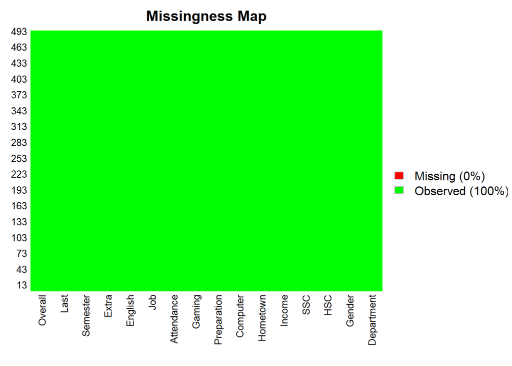

```r
missmap(data, col = c("red", "green"), margins = c(5,2))
```

```r
nrow(data)
```

```
## [1] 493
```

Zauważamy, że zbiór ten **nie posiada żadnych braków danych** oraz przechowuje **493 rekordy**.

## Dane przed zmianą ich typów

```r
summary(data)
```

```
##   Department           Gender               HSC             SSC
##  Length:493         Length:493         Min.   :2.170   Min.   :3.000
##  Class :character   Class :character   1st Qu.:3.830   1st Qu.:4.680
##  Mode  :character   Mode  :character   Median :4.170   Median :4.940
##                                        Mean   :4.157   Mean   :4.768
##                                        3rd Qu.:4.500   3rd Qu.:5.000
##                                        Max.   :5.000   Max.   :5.000
##     Income            Hometown            Computer     Preparation
##  Length:493         Length:493         Min.   :1.000   Length:493
##  Class :character   Class :character   1st Qu.:3.000   Class :character
##  Mode  :character   Mode  :character   Median :3.000   Mode  :character
##                                        Mean   :3.339
##                                        3rd Qu.:4.000
##                                        Max.   :5.000
##     Gaming           Attendance            Job               English
##  Length:493         Length:493         Length:493         Min.   :1.00
##  Class :character   Class :character   Class :character   1st Qu.:3.00
##  Mode  :character   Mode  :character   Mode  :character   Median :4.00
##                                                           Mean   :3.57
##                                                           3rd Qu.:4.00
##                                                           Max.   :5.00
##     Extra             Semester              Last          Overall
##  Length:493         Length:493         Min.   :1.000   Min.   :1.000
##  Class :character   Class :character   1st Qu.:2.810   1st Qu.:2.880
##  Mode  :character   Mode  :character   Median :3.250   Median :3.270
##                                        Mean   :3.164   Mean   :3.188
##                                        3rd Qu.:3.670   3rd Qu.:3.680
##                                        Max.   :4.000   Max.   :4.000
```

## Zmiana typów danych

```r
data$Income[data$Income == "Low (Below 15,000) "] <- "Low (Below 15,000)"
data$Income[data$Income == "Lower middle (15,000-30,000) " |
              data$Income == "Lower middle (15,000-30,000)  "] <- "Lower middle (15,000-30,000)"
data$Income[data$Income == "Upper middle (30,000-50,000) "] <- "Upper middle (30,000-50,000)"
data$Income[data$Income == "High (Above 50,000) " | data$Income =="High (Above 50,000)  "] <- "High (Above 50,000)"
```

## Zamiana typów zmiennych

```r
data$Department <- as.factor(data$Department)
data$Gender <- as.factor(data$Gender)
data$Income <- ordered(data$Income,levels=c("Low (Below 15,000)","Lower middle (15,000-30,000)",
                                            "Upper middle (30,000-50,000)","High (Above 50,000)"))
data$Hometown <- as.factor(data$Hometown)
data$Computer <- ordered(data$Computer)
data$Preparation <- ordered(data$Preparation)
data$Gaming <- ordered(data$Gaming)
data$Attendance <- ordered(data$Attendance, levels=c("Below 40%","40%-59%","60%-79%","80%-100%"))
data$Job <- as.factor(data$Job)
data$English <- ordered(data$English)
data$Extra <- as.factor(data$Extra)
data$Semester <- ordered(data$Semester, levels=c("2nd","3rd","4th","5th","6th","7th","8th","9th","10th","11th","12th"))
```

Ze względu na charakter danych oraz fakt, że większość z nich, mimo struktury odpowiadającej typowi factor, była zapisana jako character, konieczna była ich **konwersja do właściwego typu** (umożliwiającego dalszą analizę).

```r
summary(data)
```

```
##                                        Department     Gender         HSC
##  Computer Science and Engineering           :443   Female:165   Min.   :2.170
##  English                                    : 14   Male  :328   1st Qu.:3.830
##  Journalism, Communication and Media Studies: 13                Median :4.170
##  Political Science                          :  6                Mean   :4.157
##  Business Administration                    :  5                3rd Qu.:4.500
##  Economics                                  :  4                Max.   :5.000
##  (Other)                                    :  8
##       SSC                                 Income       Hometown   Computer
##  Min.   :3.000   Low (Below 15,000)          : 74   City   :213   1: 58
##  1st Qu.:4.680   Lower middle (15,000-30,000):180   Village:280   2: 42
##  Median :4.940   Upper middle (30,000-50,000):110                 3:183
##  Mean   :4.768   High (Above 50,000)         :129                 4: 95
##  3rd Qu.:5.000                                                    5:115
##  Max.   :5.000
##
##             Preparation                Gaming        Attendance   Job
##  0-1 Hour         :218   0-1 Hour         : 50   Below 40%: 11   No :459
##  2-3 Hours        :228   2-3 Hours        :141   40%-59%  : 68   Yes: 34
##  More than 3 Hours: 47   More than 3 Hours:302   60%-79%  :217
##                                                  80%-100% :197
##
##
##
##  English Extra        Semester        Last          Overall
##  1:  8   No :288   2nd    :183   Min.   :1.000   Min.   :1.000
##  2: 38   Yes:205   10th   : 57   1st Qu.:2.810   1st Qu.:2.880
##  3:176             8th    : 54   Median :3.250   Median :3.270
##  4:207             3rd    : 35   Mean   :3.164   Mean   :3.188
##  5: 64             5th    : 33   3rd Qu.:3.670   3rd Qu.:3.680
##                    9th    : 30   Max.   :4.000   Max.   :4.000
##                    (Other):101
```

# Wstępna charakterystyka badanych osób

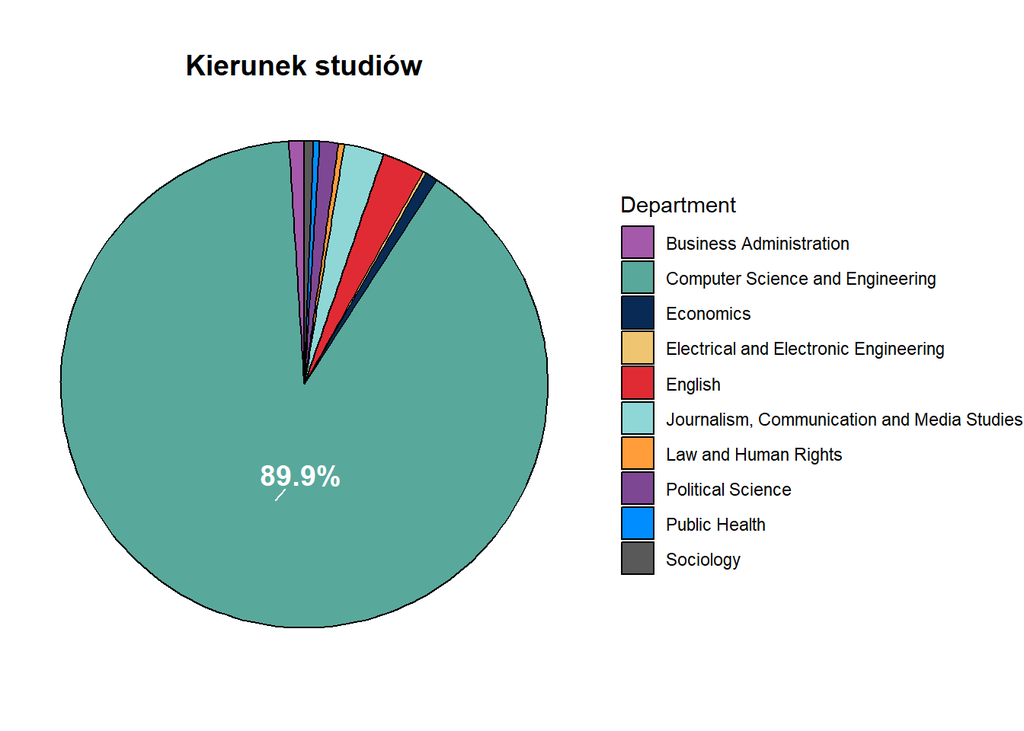

```r
Departments <- data %>%
  group_by(Department) %>%
  count() %>%
  as.data.frame()

ggplot(Departments, aes(x = "", y = n, fill = Department)) +
  geom_col(color = "black") +
  geom_text_repel(aes(label = paste0(round(n/sum(n)*100, 1), '%')),
                  position = position_stack(vjust = 0.5),
                  size = 5,
                  fontface = "bold",
                  color = "white",
                  box.padding = 0.5,
                  min.segment.length = 0) +  # Automatyczne dostosowanie pozycji etykiet
  coord_polar(theta = "y") +
  scale_fill_manual(values = c("#a559aa","#59a89c","#082a54","#f0c571","#e02b35","#8fd7d7","#ff9d3a","#7E4794","#008dff","#595959","#36b700")) +
  labs(title = "Kierunek studiów") +
  theme_void() +
  theme(plot.title = element_text(hjust = 0.5, face = "bold", size = 14))
```

Lwią część ankietowanych stanowią osoby z kierunku *“Computer Science and Engineering”*, co może świadczyć, o tym, że badane osoby mają raczej **ścisłe umysły**, o czym należy pamiętać w kontekście analizy.

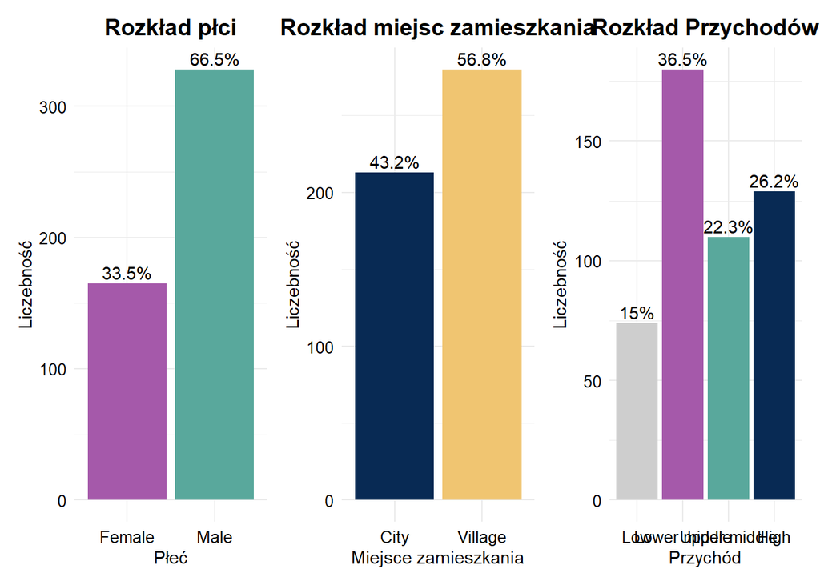

```r
Genders <- data %>%
  group_by(Gender) %>%
  count() %>%
  as.data.frame()


bar1 <- ggplot(Genders, aes(x = Gender, y = n, fill = Gender))+
  geom_bar(stat = "identity")+
  scale_fill_manual(values = c("#a559aa","#59a89c"))+
  labs(title = "Rozkład płci", x = "Płeć", y = "Liczebność")+
  theme_minimal() +
  theme(plot.title = element_text(hjust = 0.5, face = "bold", size = 14),
         axis.text = element_text(size = 10, color = "black"),
        legend.position = "none")+
  geom_text(aes(label = paste0(round(n/sum(n)*100, 1), '%'), vjust = -0.3))


Hometowns <- data %>%
  group_by(Hometown) %>%
  count() %>%
  as.data.frame()


bar2 <- ggplot(Hometowns, aes(x = Hometown, y = n, fill = Hometown))+
  geom_bar(stat = "identity")+
  scale_fill_manual(values = c("#082a54","#f0c571"))+
  labs(title = "Rozkład miejsc zamieszkania", x = "Miejsce zamieszkania", y = "Liczebność")+
  theme_minimal() +
  theme(plot.title = element_text(hjust = 0.5, face = "bold", size = 14),
         axis.text = element_text(size = 10, color = "black"),
        legend.position = "none")+
  geom_text(aes(label = paste0(round(n/sum(n)*100, 1), '%'), vjust = -0.3))



Incomes <- data %>%
  group_by(Income) %>%
  count() %>%
  as.data.frame()

bar3 <- ggplot(Incomes, aes(x = Income, y=n, fill = Income))+
  geom_bar(stat = "identity")+
  scale_fill_manual(values = c("#cecece","#a559aa","#59a89c","#082a54"))+
  scale_x_discrete(labels = c('Low', 'Lower middle', 'Upper middle', 'High'))+
  labs(title = "Rozkład Przychodów", x = "Przychód", y = "Liczebność")+
  theme_minimal() +
  theme(plot.title = element_text(hjust = 0.5, face = "bold", size = 14),
         axis.text = element_text(size = 10, color = "black"),
        legend.position = "none")+
  geom_text(aes(label = paste0(round(n/sum(n)*100, 1), '%'), vjust = -0.3))





Semesters <- data %>%
  group_by(Semester) %>%
  count() %>%
  as.data.frame()

bar4 <- ggplot(Semesters, aes(x = n, y=Semester, fill = Semester))+
  geom_bar(stat = "identity")+
  scale_fill_manual(values = c("#a559aa","#59a89c","#082a54","#f0c571","#e02b35","#8fd7d7","#ff9d3a","#7E4794","#008dff","#595959","#36b700"))+
  labs(title = "Rozkład według semestru studiów", x = "Liczebność", y = "Semestr")+
  theme_minimal() +
  theme(plot.title = element_text(hjust = 0.5, face = "bold", size = 14),
         axis.text = element_text(size = 10, color = "black"),
        legend.position = "none")+
  geom_text(aes(label = paste0(round(n/sum(n)*100, 1), '%'), vjust = 0.5, hjust=-0.1))



(bar1 | bar2 | bar3)
```

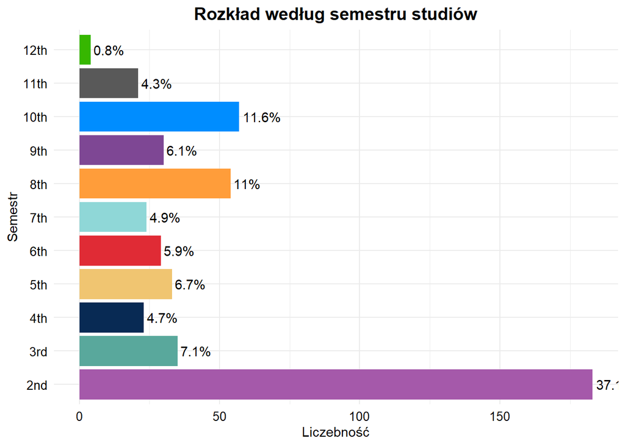

```r
bar4
```

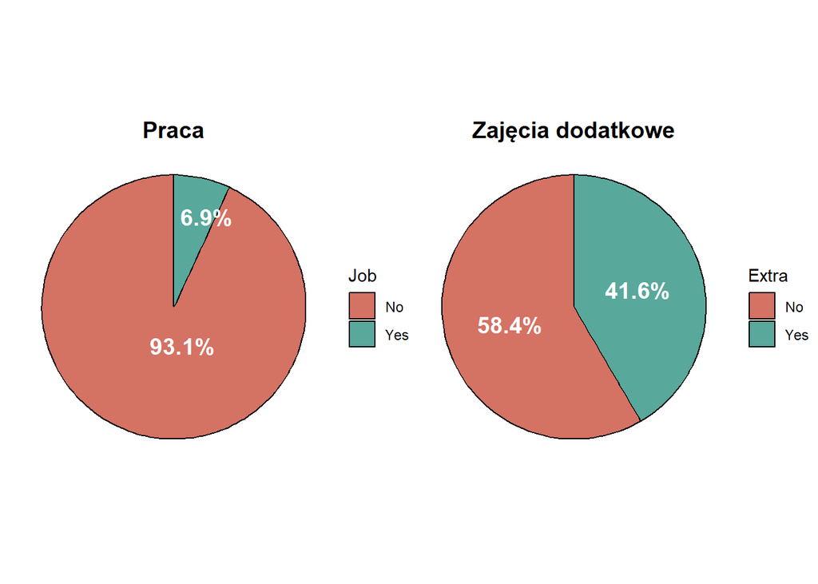

```r
Jobs <- data %>%
  group_by(Job) %>%
  count() %>%
  as.data.frame()


pie1 <- ggplot(Jobs, aes(x = "", y = n, fill = Job)) +
  geom_col(color = "black") +
  geom_text(aes(label = paste0(round(n/sum(n)*100, 1), '%')),
            position = position_stack(vjust = 0.5),
            size = 5,
            fontface = "bold",
            color = "white",
            hjust = 0.15,
            vjust = -1
            ) +
  coord_polar(theta = "y") +
  scale_fill_manual(values = c("#d47264","#59a89c"))+
  labs(title = "Praca")+
  theme_void()+
  theme(plot.title = element_text(hjust = 0.5, face = "bold", size = 14))


Extras <- data %>%
  group_by(Extra) %>%
  count() %>%
  as.data.frame()

pie2 <- ggplot(Extras, aes(x = "", y = n, fill = Extra)) +
  geom_col(color = "black") +
  geom_text(aes(label = paste0(round(n/sum(n)*100, 1), '%')),
            position = position_stack(vjust = 0.5),
            size = 5,
            fontface = "bold",
            color = "white")+
  coord_polar(theta = "y") +
  scale_fill_manual(values = c("#d47264","#59a89c"))+
  labs(title = "Zajęcia dodatkowe")+
  theme_void()+
  theme(plot.title = element_text(hjust = 0.5, face = "bold", size = 14))


(pie1 | pie2)
```

Większość ankietowanych nie posiada pracy. Natomiast w kontekście uczestnictwa w zajęciach dodatkowych przeważają osoby, które nie biorą udziału w tego rodzaju aktywnościach.

# Zależności między zmiennymi

## Zmienne kategoryczne

### Test Chi kwadrat oraz Współczynnik V - Cramera

**Test Chi-kwadrat** służy do sprawdzania zależności między zmiennymi kategorycznymi (które stanowią 12/16 zmiennych w badanym zbiorze). Porównuje oczekiwane częstości z zaobserwowanymi w tabeli kontyngencji, aby ocenić, czy różnice są istotne statystycznie.  
**Współczynnik V-Cramera** to miara siły związku między zmiennymi kategorycznymi, obliczana na podstawie wyniku testu Chi-kwadrat. Przyjmuje wartości od 0 (brak związku) do 1 (silny związek), co pozwala określić stopień powiązania między zmiennymi.

```r
categorical_vars <- c("Department", "Gender", "Income", "Hometown", "Computer",
                      "Gaming", "Attendance", "English", "Extra", "Semester", "Job","Preparation")

# podzbiór danych tylko z tymi kategorycznymi zmiennymi
data[categorical_vars] <- lapply(data[categorical_vars], as.factor)

n <- length(categorical_vars)
p_values <- matrix(NA, n, n, dimnames = list(categorical_vars, categorical_vars))
cramers_v <- matrix(NA, n, n, dimnames = list(categorical_vars, categorical_vars))



for (i in 1:(n-1)) {
  for (j in (i+1):n) {
    # tabela kontyngencji
    table_temp <- table(data[[categorical_vars[i]]], data[[categorical_vars[j]]])

    # Obliczenie oczekiwanych wartości
    expected <- chisq.test(table_temp)$expected


    if ((sum(expected < 5) / length(expected) <= 0.2)) {
      # Test chi-kwadrat
      chi_test <- chisq.test(table_temp)
      p_values[i, j] <- chi_test$p.value
      p_values[j, i] <- chi_test$p.value  # macierz symetryczna

      # Obliczanie Cramér's V dla istotnych wyników
      if (chi_test$p.value < 0.05) {
        cramers_v_value <- assocstats(table_temp)$cramer
        cramers_v[i, j] <- cramers_v_value
        cramers_v[j, i] <- cramers_v_value  # macierz symetryczna
      }
    } else {
      # Jeśli założenie nie jest spełnione, pozostaw NA
      p_values[i, j] <- NA
      p_values[j, i] <- NA
      cramers_v[i, j] <- NA
      cramers_v[j, i] <- NA
    }
  }
}
```

### Wizualizacja otrzymanych wyników

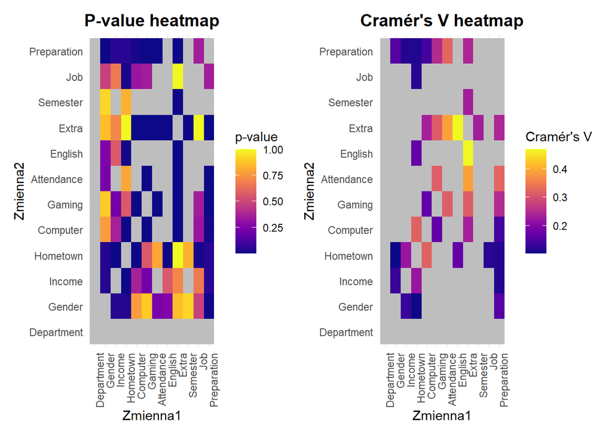

```r
p_values_df <- as.data.frame(as.table(p_values))
colnames(p_values_df) <- c("Zmienna1", "Zmienna2", "p_value")

chi <- ggplot(p_values_df, aes(x = Zmienna1, y = Zmienna2, fill = p_value)) +
  geom_tile() +
  scale_fill_viridis(option = "plasma", na.value = "grey") +
  theme_minimal() +
  labs(title = "P-value heatmap", fill = "p-value")+
  theme(plot.title = element_text(hjust = 0.5, face = "bold", size = 14),
        axis.text.x = element_text(angle = 90, hjust = 1))





cramers_v_df <- as.data.frame(as.table(cramers_v))
colnames(cramers_v_df) <- c("Zmienna1", "Zmienna2", "Cramers_V")

cram <- ggplot(cramers_v_df, aes(x = Zmienna1, y = Zmienna2, fill = Cramers_V)) +
  geom_tile() +
  scale_fill_viridis(option = "plasma", na.value = "grey") +
  theme_minimal() +
  labs(title = "Cramér's V heatmap", fill = "Cramér's V")+
  theme(plot.title = element_text(hjust = 0.5, face = "bold", size = 14),
        axis.text.x = element_text(angle = 90, hjust = 1))


(chi | cram)
```

Spośród obliczonych wartości p-value wybieramy, te pary zmiennych dla których wartość jest **mniejsza/równa 0,05** (odcienie granatowe). Dodatkowo sprawdzone zostało założenie, że **maksymalnie 20% komórek w tabeli kontyngencji może mieć oczekiwaną częstość mniejszą niż 5**. Jeśli ten warunek nie byłby spełniony, wyniki testu mogłby być niewiarygodne.  
Dla par spełniających powyższe warunki obliczony został współczynnik V Cramera, w przypadku którego większa wartość świadczy o większej sile związku.

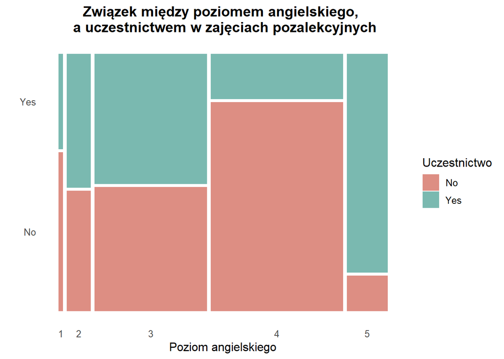

```r
ggplot(data) +
  geom_mosaic(aes(x = product(English), fill = Extra), color = "white") +
  labs(
    title = "Związek między poziomem angielskiego, \n a uczestnictwem w zajęciach pozalekcyjnych",
    x = "Poziom angielskiego", y = "", fill = "Uczestnictwo")+
  theme_minimal(base_size = 12) +
  theme(plot.title = element_text(hjust = 0.5, face = "bold"),
    panel.grid.major = element_blank())+
  scale_fill_manual(values = c("#d47264","#59a89c"))
```

Wykres ten niesie za sobą niezywkle ciekawą, a zarazem niespodziewaną konkluzję. Zauważamy, że wśród osób oceniających swoje zdolności komunikacji w języku angielskim na 4 większość nie uczestniczy w zajęciach dodatkowych. Natomiast przy ocenie zdolności językowych na poziomie o jeden wiekszym (5) obserwujemy odwrotną tendencję – przeważają osoby biorące udział w takich zajęciach.  
Jedną z potencjalnych przyczyn tak nieoczekiwanej zależności może być **przecenianie swoich zdolności językowych** przez osoby ankietowane. Zaangażowanie w zajęcia dodatkowe może bowiem wynikać z większej pewności siebie osób lepiej komunikujących się w języku angielskim lub z faktu, że takowe aktywności częściej wymagają takich umiejętności, co zachęca osoby o wyższym poziomie języka do udziału.

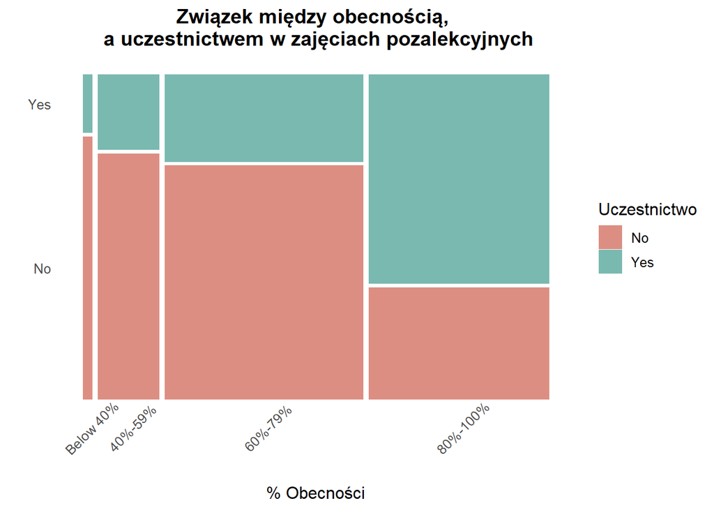

```r
ggplot(data) +
  geom_mosaic(aes(x = product(Attendance), fill = Extra), color = "white") +
  labs(
    title = "Związek między obecnością, \n a uczestnictwem w zajęciach pozalekcyjnych",
    x = "% Obecności", y = "", fill = "Uczestnictwo")+
  theme_minimal(base_size = 12) +
  theme(plot.title = element_text(hjust = 0.5, face = "bold"),
    panel.grid.major = element_blank(),
    axis.text.x = element_text(angle = 45, hjust = 0.5))+
  scale_fill_manual(values = c("#d47264","#59a89c"))
```

Powyższy wykres ujawnia niemalże *“liniową”* zależność pomiędzy procentem obecności na zajęciach, a uczestnictwem w zajęciach dodatkowych - wraz ze wzrostem obecności, rośnie także odsetek osób biorących udział w aktywnościach pozalekcyjnych. Może to świadczyć o lepszej zdolności do zarządzania czasem przez osoby angażujące się w zajęcia dodatkowe. Wzrost liczby obowiązków może sprzyjać wyższemu poziomowi dyscypliny oraz sygnalizować wyższy poziom ambitności.

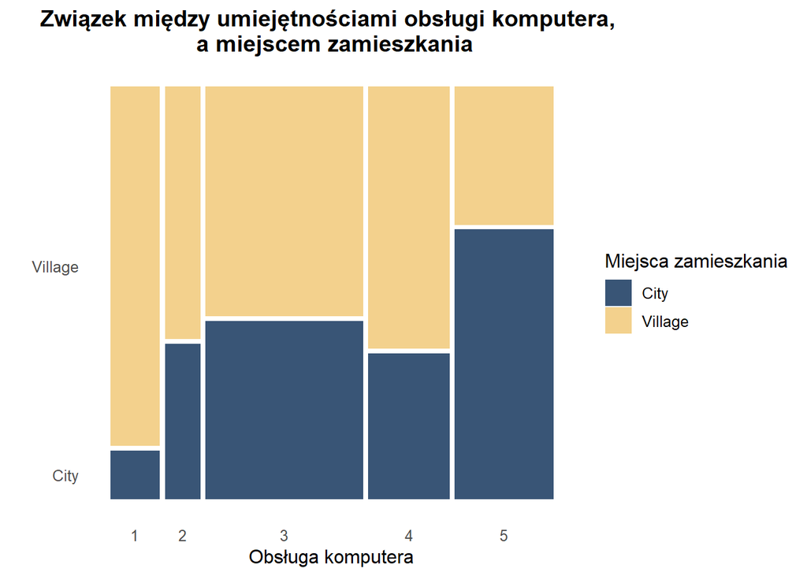

```r
 ggplot(data) +
  geom_mosaic(aes(x = product(Computer), fill = Hometown), color = "white") +
  labs(
    title = "Związek między umiejętnościami obsługi komputera, \n a miejscem zamieszkania",
    x = "Obsługa komputera", y = "", fill = "Miejsca zamieszkania")+
  theme_minimal(base_size = 12) +
  theme(plot.title = element_text(hjust = 0.5, face = "bold"),
    panel.grid.major = element_blank(),)+
  scale_fill_manual(values = c("#082a54","#f0c571"))
```

Szczególną uwagę warto zwrócić na skrajne wartości przy poziomie obsługi komputera. Ujawniają one bowiem intuicyjną, a zaraz stereotypową zależność - osoby pochodzące ze wsi znacznie słabiej *(1)* radzą sobie z używaniem technologii niźli osoby pochodzące z miast *(5)*.

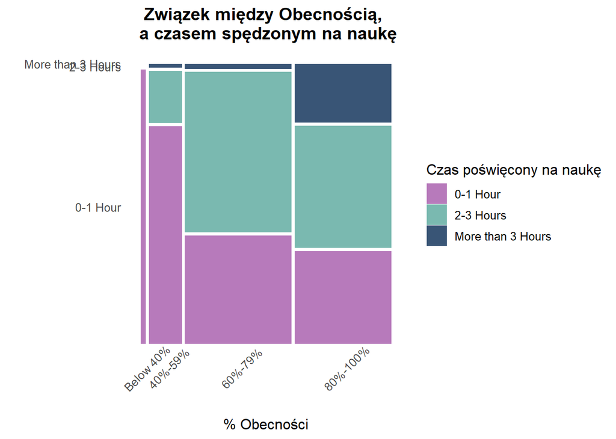

```r
ggplot(data) +
  geom_mosaic(aes(x = product(Attendance), fill = Preparation), color = "white") +
  labs(
    title = "Związek między Obecnością, \n a czasem spędzonym na naukę",
    x = "% Obecności", y = "", fill = "Czas poświęcony na naukę")+
  theme_minimal(base_size = 12) +
  theme(plot.title = element_text(hjust = 0.5, face = "bold"),
    panel.grid.major = element_blank(),
    axis.text.x = element_text(angle = 45, hjust = 0.5))+
  scale_fill_manual(values = c("#a559aa","#59a89c","#082a54"))
```

Wnioskiem płynącym z powyższej wizualizacji jest fakt, iż wraz ze wzrostem procentu obecności na zajęciach rośnie także liczba godzin poświęconych na samodzielną naukę. Sugeruje to ambitność osób, które pomimo uczestnictwa w zajęciach starają się poświęcać swój wolny czas na dodatkowe pozyskiwanie wiedzy i trenowanie zdobytych umiejętności.

## Zmienne numeryczne

### Poszukiwanie zależności

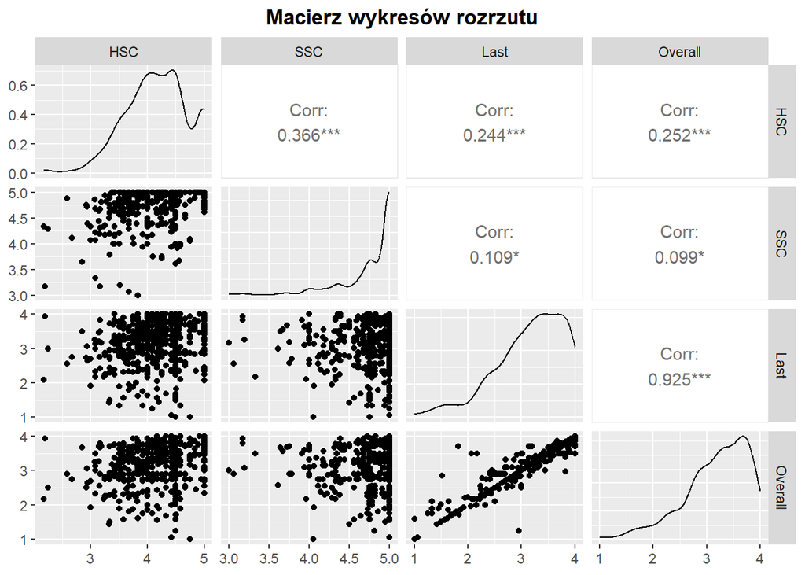

```r
data2 <- data %>%
  select(HSC,SSC,Last,Overall) %>%
  as.data.frame()

ggpairs(data2)+
  labs(title = "Macierz wykresów rozrzutu")+
  theme(plot.title = element_text(hjust = 0.5, face = "bold"))
```

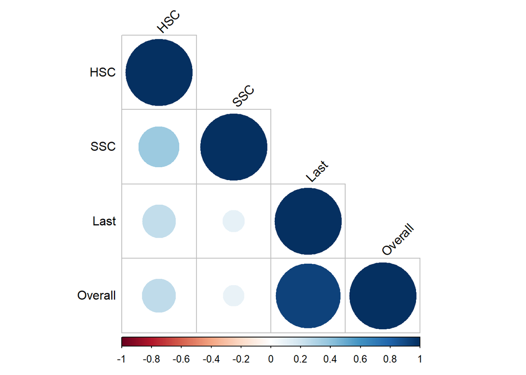

```r
cor_matrix <- cor(data2, use = "complete.obs")
corrplot(cor_matrix, method = "circle", type = "lower", tl.col = "black", tl.srt = 45)
```

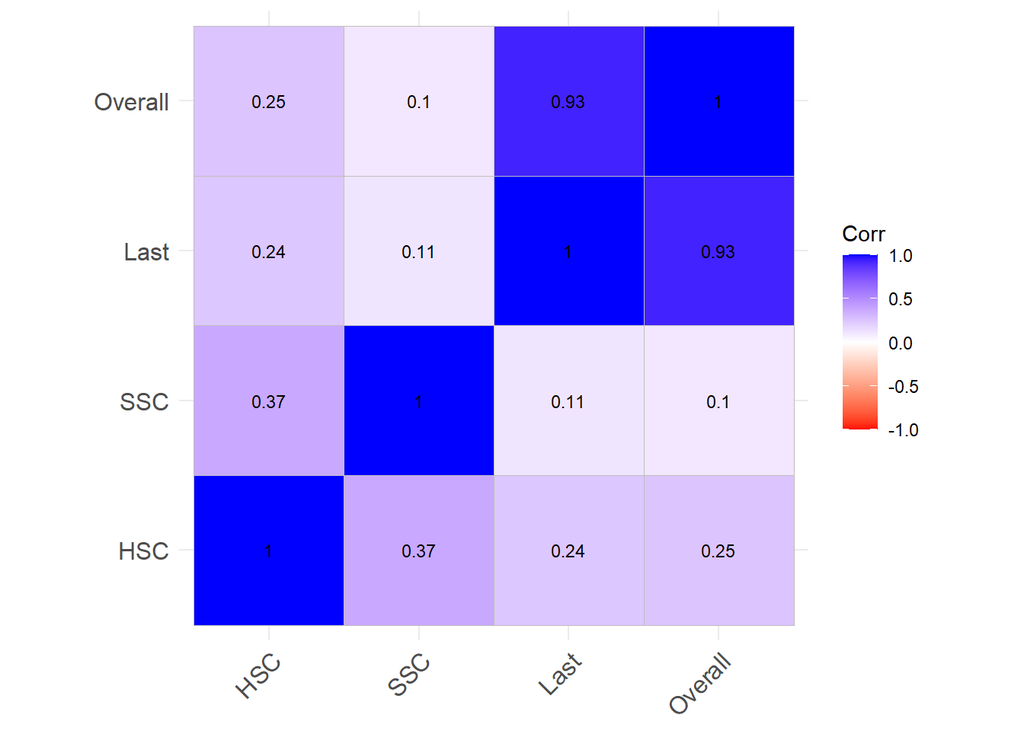

```r
ggcorrplot(cor_matrix, lab = TRUE, lab_size = 3, method = "square", colors = c("red", "white", "blue"))
```

Powyższe wykresy nakreśliły wstępne zależności, które warto było zbadać. W szczególności przedstawiają one wykresy gęstości, wykresy rozrzutu dla każdej pary zmiennych oraz współczynnik korelacji.  
Jedyną parą zmiennych, dla której można dostrzec zależność są zmienne *Last* oraz *Overall*.

### Wizualizacje

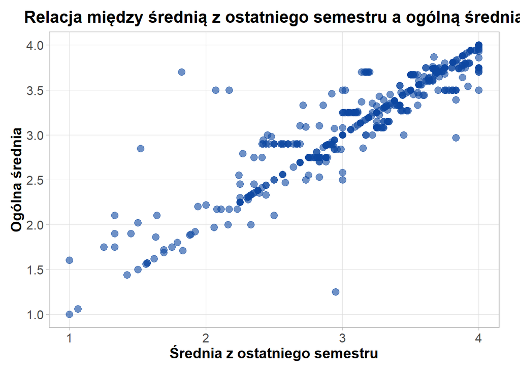

```r
ggplot(data, aes(x = Last, y = Overall)) +
  # Punkty
  geom_point(alpha = 0.6, color = "#0D47A1", size = 3) +
  # Tytuł i etykiety
  labs(
    title = "Relacja między średnią z ostatniego semestru a ogólną średnią",
    x = "Średnia z ostatniego semestru",
    y = "Ogólna średnia"
  ) +
  # Motyw wykresu
  theme_light() +
  theme(plot.title = element_text(hjust = 0.5, size = 16, face = "bold"),
    axis.title = element_text(size = 14, face = "bold"),
    axis.text = element_text(size = 12),
    panel.grid.minor = element_blank(),  # Brak siatki pomocniczej
    plot.margin = margin(10, 20, 10, 10)) +
  scale_x_continuous(breaks = seq(min(data$Last), max(data$Last), by = 1)) +
  scale_y_continuous(breaks = seq(min(data$Overall), max(data$Overall), by = 0.5))
```

Dla wspomnianych zmiennych wykreślony rysunek ukazuje ich niemalże **liniową** zależność, co dowodzi, że średnia z ostatniego semestru wpływa na średnią ogółem. Im wyższa jest pierwsza z nim, tym wyższa jest także ta druga.

## Różne typy zmiennych

Analiza zależności pomiędzy różnymi typami zmiennych pozwoliła uzyskać odpowiedzi na postawione w projekcie **problemy badawcze** oraz **hipotezy**.

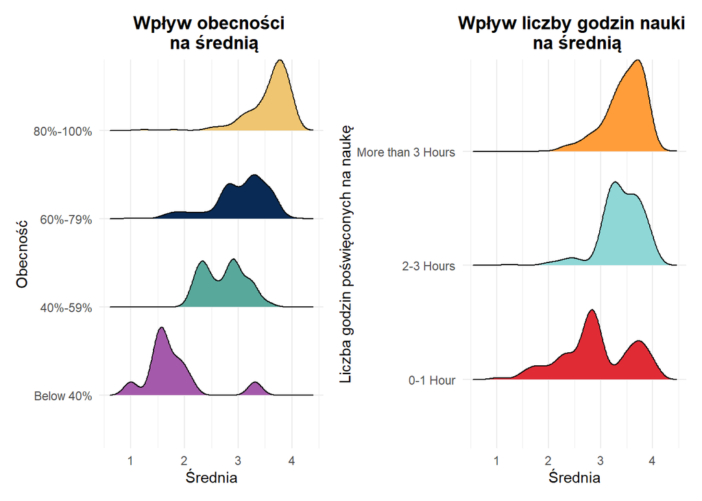

```r
h3a <- ggplot(data, aes(y = Attendance, x = Overall, fill = Attendance))+
  geom_density_ridges( alpha = 1, scale = 0.8)+
  scale_fill_manual(values = c("#a559aa","#59a89c","#082a54","#f0c571"))+
  labs(title= "Wpływ obecności \n na średnią",
      x= "Średnia",
      y = "Obecność")+
  theme_minimal()+
  theme(plot.title = element_text(hjust = 0.5, face="bold"),
    legend.position = "none")

h3b <- ggplot(data, aes(y = Preparation, x = Overall, fill = Preparation))+
  geom_density_ridges( alpha = 1, scale = 0.8)+
  scale_fill_manual(values = c("#e02b35","#8fd7d7","#ff9d3a"))+
  labs(title= "Wpływ liczby godzin nauki \n na średnią",
      x= "Średnia",
      y = "Liczba godzin poświęconych na naukę")+
  theme_minimal()+
  theme(plot.title = element_text(hjust = 0.5, face="bold"),
    legend.position = "none")

(h3a | h3b)
```

Wizualizacje te pozwalają odpowiedzieć na hipotezę oraz problem badawczy nr *3*.  
Hipotezę możemy przyjąć za prawdziwą, gdyż zauważamy, iż wraz ze wzrostem godzin poświęconych na naukę/procentem obecności rośnie także średnia ocen.  
Z kolei w nawiązaniu do problemu badawczego stwierdzamy, że regularna obecność na zajęciach wpływa w pozytywny sposób na wyniki akademickie.

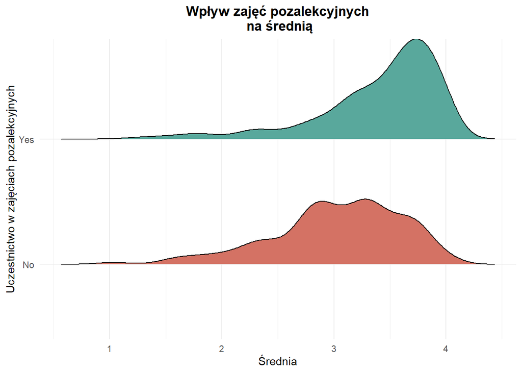

```r
h2 <-  ggplot(data, aes(y = Extra, x = Overall, fill = Extra))+
  geom_density_ridges( alpha = 1, scale = 0.8)+
  scale_fill_manual(values = c("#d47264","#59a89c"))+
  labs(title= "Wpływ zajęć pozalekcyjnych\n na średnią",
      x= "Średnia",
      y = "Uczestnictwo w zajęciach pozalekcyjnych")+
  theme_minimal()+
  theme(plot.title = element_text(hjust = 0.5, face="bold"),
    legend.position = "none")

h2
```

Wizualizacja ta pozwala odpowiedzieć na hipotezę oraz problem badawczy nr *2*.  
Hipoteza ponownie okazała się być trafna, zgodnie z powyższym wykresem widzimy, że osoby uczestniczące w zajęciach dodatkowych osiągają lepsze wyniki w nauce niż ci, którzy nie biorą udziału w takich zajęciach.  
Z kolei w nawiązaniu do problemu badawczego stwierdzamy, iż aktywności pozalekcyjne mają pozytywny wpływ na wyniki akademickie studentów.

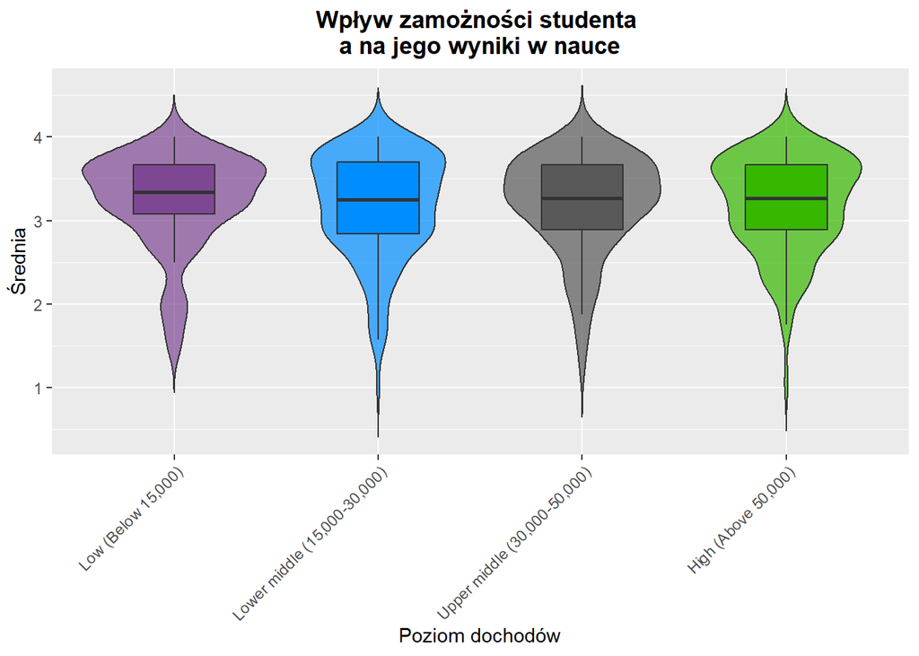

```r
ggplot(data, aes(x=Income, y=Overall, fill=Income))+
  geom_violin(trim=FALSE, alpha=0.7)+
  scale_fill_manual(values = c("#7E4794","#008dff","#595959","#36b700"))+
  geom_boxplot(width= 0.4, outlier.shape = NA)+
  labs(title = "Wpływ zamożności studenta \na na jego wyniki w nauce",
       x="Poziom dochodów",
       y="Średnia")+
  theme(plot.title = element_text(hjust = 0.5, face="bold"),
        legend.position = "none")+
   theme(axis.text.x = element_text(angle = 45, hjust = 1))
```

Wykres ten pozwala odpowiedzieć na hipotezę nr *1*.  
Odrzucamy ją, gdyż zauważamy, że poziom dochodów w rodzinie studenta nie ma zauważalnego wpływu na jego wyniki w nauce. Mediana i rozkład dla każdego z poziomu dochodów są względnie na podobnym poziomie.

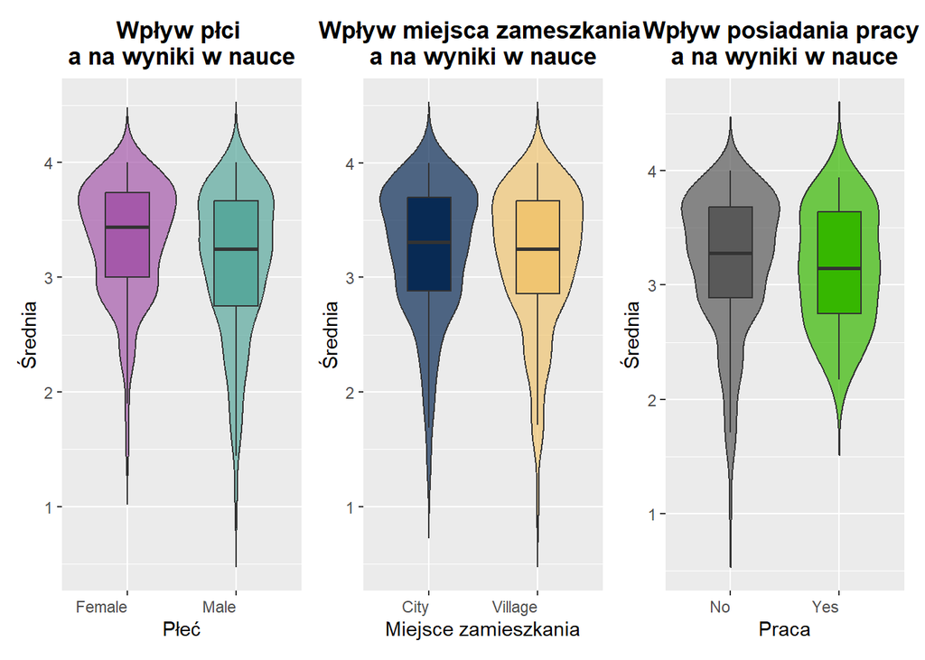

```r
vb1 <- ggplot(data, aes(x=Gender, y=Overall, fill=Gender))+
  geom_violin(trim=FALSE, alpha=0.7)+
  geom_boxplot(width= 0.4, outlier.shape = NA)+
  scale_fill_manual(values = c("#a559aa","#59a89c"))+
  labs(title = "Wpływ płci \na na wyniki w nauce",
       x="Płeć",
       y="Średnia")+
  theme(plot.title = element_text(hjust = 0.5, face="bold"),
        legend.position = "none")+
   theme(axis.text.x = element_text(hjust = 1))

vb2 <- ggplot(data, aes(x=Hometown, y=Overall, fill=Hometown))+
  geom_violin(trim=FALSE, alpha=0.7)+
  geom_boxplot(width= 0.4, outlier.shape = NA)+
  scale_fill_manual(values = c("#082a54","#f0c571"))+
  labs(title = "Wpływ miejsca zameszkania \na na wyniki w nauce",
       x="Miejsce zamieszkania",
       y="Średnia")+
  theme(plot.title = element_text(hjust = 0.5, face="bold"),
        legend.position = "none")+
   theme(axis.text.x = element_text(hjust = 1))


vb3 <- ggplot(data, aes(x=Job, y=Overall, fill=Job))+
  geom_violin(trim=FALSE, alpha=0.7)+
  geom_boxplot(width= 0.4, outlier.shape = NA)+
  scale_fill_manual(values = c("#595959","#36b700"))+
  labs(title = "Wpływ posiadania pracy \na na wyniki w nauce",
       x="Praca",
       y="Średnia")+
  theme(plot.title = element_text(hjust = 0.5, face="bold"),
        legend.position = "none")+
   theme(axis.text.x = element_text(hjust = 1))


vb1 | vb2 | vb3
```

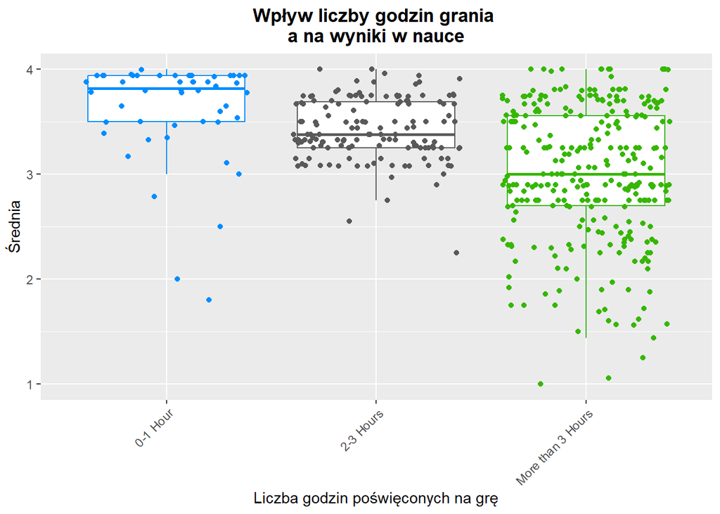

```r
ggplot(data, aes(x = Gaming , y = Overall, colour = Gaming))+
  geom_boxplot(outlier.shape = NA) +
  geom_jitter()+
  scale_colour_manual(values = c("#008dff","#595959","#36b700"))+
  labs(title = "Wpływ liczby godzin grania \na na wyniki w nauce",
       x="Liczba godzin poświęconych na grę",
       y="Średnia")+
  theme(plot.title = element_text(hjust = 0.5, face="bold"),
        legend.position = "none")+
   theme(axis.text.x = element_text(angle = 45, hjust = 1))
```

Z kolei powyższe wizualizacje nawiązują do problemu badawczego nr *1*.  
Stwierdzić można bowiem, iż żaden z czynników: poziom dochodu, miejsce zamieszkania, posiadanie pracy nie wpływa znacząco na wyniki osiągane podczas studiów. W kontekście płci zauważamy lekką przewagę kobiet nad mężczyznami. Wpływ na średnią ma jednak liczba godzin poświęconych na gry - im mniejsza, tym lepsze wyniki w nauce (należy jednak mieć na uwadze nierównomierne rozłożenie obserwacji wśród kategorii).

# Sylwetka idealnego kandydata (?)

```r
best2 <- data %>%
  filter(Gender == "Female",
         Hometown == "City",
         Job == "No",
         Extra == "Yes", #wpływa na obecnosc, a ta na oceny
         Gaming == "0-1 Hour") %>%
  as.data.frame()

mean(best2$Overall)
```

```
## [1] 3.7597
```

W wyniku powyższej analizy naturalnym wydawało się tworzenie sylwetki kandydata idealnego *(w odpowiedzi na postawione w projekcie wyzwania)*. Po zastosowaniu odpowiednich kryteriów otrzymano zbiór osób których średnia ocen wynosi **3,75** (gdzie 4,0 stanowi maksymalną możliwą do zdobycia średnią). Problem jednak stanowi mała reprezentatywność próbki, gdyż jest to tylko i wyłącznie 10 osób.

# Klastrowanie zbioru

Pozostając w obowiązku reakcji na poruszony powyżej problem, postanowiono dokonać klastryzacji zbioru.

## Szukanie odpowiedniej liczby klastrów

Zadanie to rozpoczęło się od znalezienia optymalnej liczby klastrów przy zastosowaniu **kryterium sylwetkowego** oraz **metody łokciowej**.

### Kryterium sylwetkowe

```r
data_for_clustering <- data
#wektor na wyniki
silhouette_scores <- numeric()

#petla obliczajaca wyniki dla roznej liczby klastrow
for (k in 2:10) {
  kproto_model <- kproto(data_for_clustering, k = k)
  sil <- silhouette(kproto_model$cluster, dist(data_for_clustering)) #wskaznik sylwetki
  silhouette_scores[k] <- mean(sil[, 3]) # Średnia wartość wskaźnika Sylwetki
}
```

[output not shown]

[output not shown]

[output not shown]

[output not shown]

[output not shown]

[output not shown]

[output not shown]

[output not shown]

[output not shown]

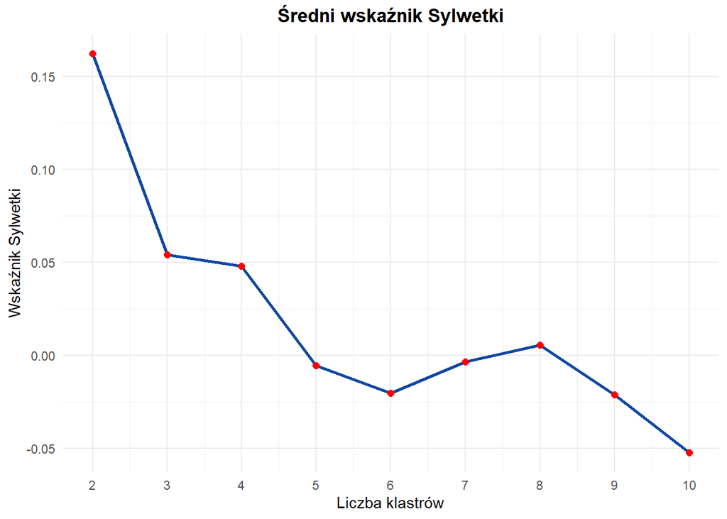

```r
sil_df <- data.frame(k = 2:10, Silhouette = silhouette_scores[2:10])

ggplot(sil_df, aes(x = k, y = Silhouette)) +
  geom_line(color = "#0D47A1", size = 1) +
  geom_point(color = "red", size = 2) +
  labs(title = "Średni wskaźnik Sylwetki", x = "Liczba klastrów", y = "Wskaźnik Sylwetki") +
  theme_minimal()+
  theme(plot.title = element_text(hjust = 0.5, face="bold"))+
    scale_x_continuous(breaks = seq(1, 10, by = 1))
```

### Metoda Łokciowa

```r
set.seed(123)

#wektor na wyniki
wcss <- numeric()

#petla obliczajaca wyniki dla roznej liczby klastrow
for (k in 1:10) {
  kproto_model <- kproto(data_for_clustering, k = k)
  wcss[k] <- kproto_model$tot.withinss #WCSS(suma kwadratów odchyleń wewnątrz klastrów) dla danego k
}
```

[output not shown]

[output cut: 54 more lines]

[output not shown]

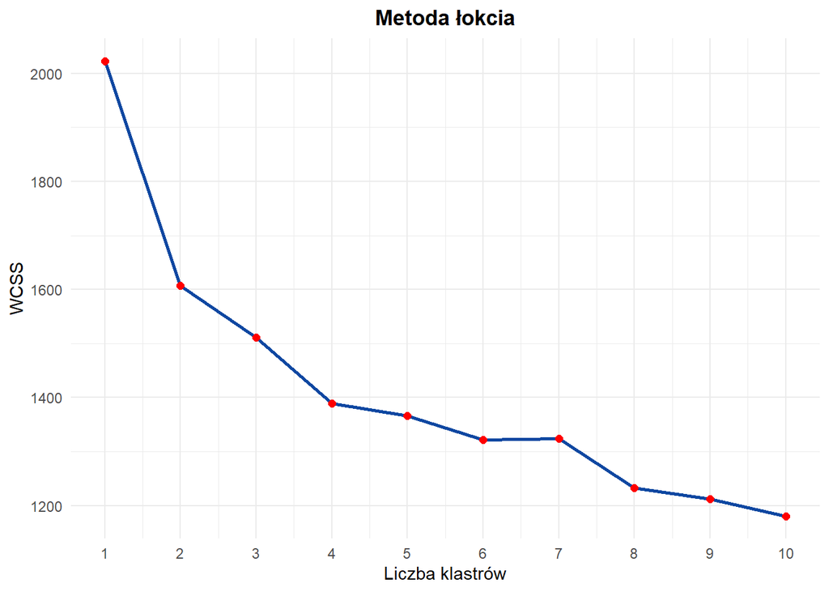

```r
elbow_df <- data.frame(k = 1:10, WCSS = wcss[1:10])

ggplot(elbow_df, aes(x = k, y = WCSS)) +
  geom_line(color = "#0D47A1", size = 1) +
  geom_point(color = "red", size = 2) +
  labs(title = "Metoda łokcia",
       x = "Liczba klastrów", y = "WCSS") +
  theme_minimal()+
  theme(plot.title = element_text(hjust = 0.5, face="bold"))+
    scale_x_continuous(breaks = seq(1, 10, by = 1))
```

W przypadku kryterium sylwetkowego szukamy liczby klastrów, dla której wskaźnik sylwetki jest najwyższy. Zaś metoda łokciowa polega na odnlezieniu *“łokcia”* na wykresie. Obie metody dały pokrywające się wyniki - 2 jest optymalną liczbą klastrów.

## Klastrowaie za pomocą algorytmu kprototypes

```r
#podzial zmiennych (wymaga tego kprototypes)
categorical_columns <- c("Department", "Gender", "Hometown", "Computer",
                         "Job", "Extra", "Semester", "Attendance",
                         "English", "Gaming", "Preparation")
numerical_columns <- c("HSC", "SSC", "Last", "Overall")

#kopia danych (zmienne kategoryczna sa juz typu factor)
data_for_clustering <- data


#normalizacja zmiennych numerycznych
preProc <- preProcess(data_for_clustering[numerical_columns], method = c("center", "scale"))
#center- przesuniecie aby srednia byla 0
#scale dzielone przez odchylenie standardowe
data_for_clustering[numerical_columns] <- predict(preProc, data_for_clustering[numerical_columns])



# Dopasowanie modelu k-prototypes
set.seed(123)
kproto_model <- kproto(data_for_clustering, k = 2) #k=2 z wczesniejszej analizy
```

```
## # NAs in variables:
##  Department      Gender         HSC         SSC      Income    Hometown
##           0           0           0           0           0           0
##    Computer Preparation      Gaming  Attendance         Job     English
##           0           0           0           0           0           0
##       Extra    Semester        Last     Overall
##           0           0           0           0
## 0 observation(s) with NAs.
##
## Estimated lambda: 1.862009
```

```r
data$Cluster <- kproto_model$cluster

#wynik
print(kproto_model)
```

```
## Distance type: huang
##
## Numeric predictors: 4
## Categorical predictors: 12
## Lambda: 1.862009
##
## Number of Clusters: 2
## Cluster sizes: 286 207
## Within cluster error: 3329.195 2261.964
##
## Cluster prototypes:
##                         Department Gender        HSC        SSC
## 1 Computer Science and Engineering   Male  0.2428174  0.1208684
## 2 Computer Science and Engineering   Male -0.3354868 -0.1669969
##                         Income Hometown Computer Preparation            Gaming
## 1 Lower middle (15,000-30,000)  Village        3   2-3 Hours More than 3 Hours
## 2 Lower middle (15,000-30,000)  Village        3    0-1 Hour More than 3 Hours
##   Attendance Job English Extra Semester       Last    Overall
## 1   80%-100%  No       3   Yes      2nd  0.6161225  0.6325915
## 2    60%-79%  No       4    No      2nd -0.8512611 -0.8740153
```

```r
head(data)
```

```
##                         Department Gender  HSC  SSC
## 1          Business Administration   Male 4.17 4.84
## 2          Business Administration Female 4.92 5.00
## 3          Business Administration   Male 5.00 4.83
## 4          Business Administration   Male 4.00 4.50
## 5          Business Administration Female 2.19 3.17
## 6 Computer Science and Engineering   Male 4.75 4.05
##                         Income Hometown Computer       Preparation
## 1           Low (Below 15,000)  Village        3 More than 3 Hours
## 2 Upper middle (30,000-50,000)     City        3          0-1 Hour
## 3 Lower middle (15,000-30,000)  Village        3          0-1 Hour
## 4          High (Above 50,000)     City        5 More than 3 Hours
## 5 Lower middle (15,000-30,000)  Village        3          0-1 Hour
## 6 Lower middle (15,000-30,000)  Village        3          0-1 Hour
##              Gaming Attendance Job English Extra Semester  Last Overall Cluster
## 1          0-1 Hour   80%-100%  No       3   Yes      6th 3.220   3.350       1
## 2          0-1 Hour   80%-100%  No       3   Yes      7th 3.467   3.467       1
## 3 More than 3 Hours   80%-100%  No       4   Yes      3rd 4.000   3.720       1
## 4 More than 3 Hours   80%-100%  No       5   Yes      4th 3.800   3.750       1
## 5         2-3 Hours   80%-100%  No       3   Yes      4th 3.940   3.940       1
## 6 More than 3 Hours  Below 40%  No       4    No      2nd 1.000   1.000       2
```

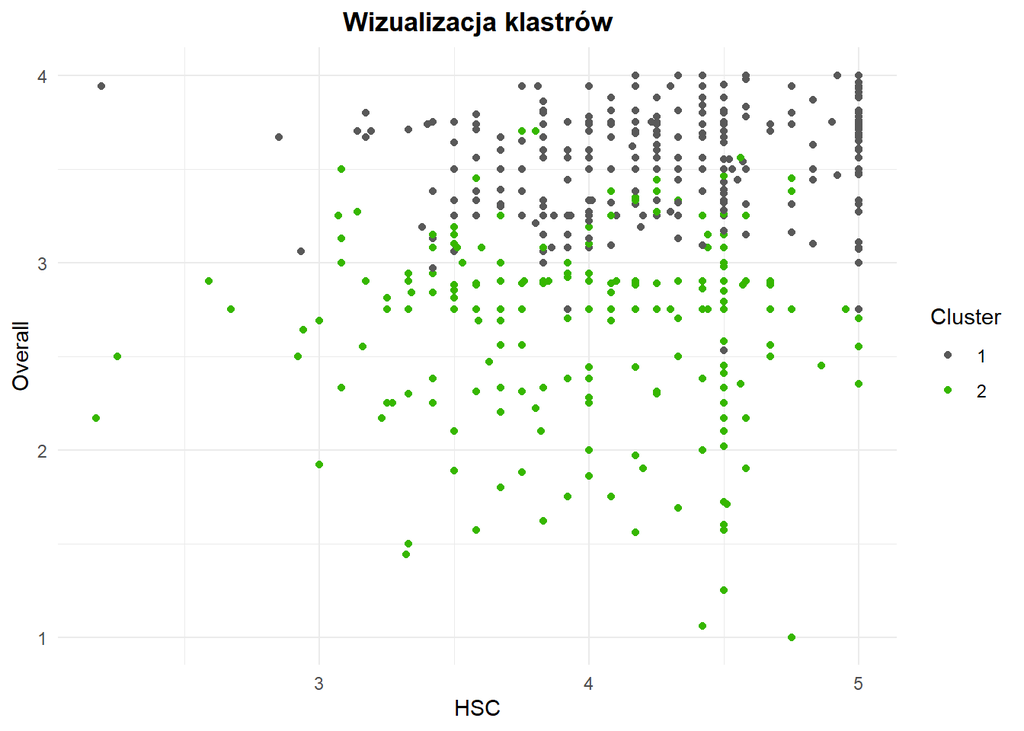

```r
data$Cluster <- as.factor(data$Cluster)

ggplot(data, aes(x = HSC, y = Overall, color = Cluster)) +
  geom_point() +
    scale_color_manual(values = c("#595959", "#36b700")) +
  labs(title = "Wizualizacja klastrów", x = "HSC", y = "Overall") +
  theme_minimal()+
  theme(plot.title = element_text(hjust = 0.5, face="bold"))
```

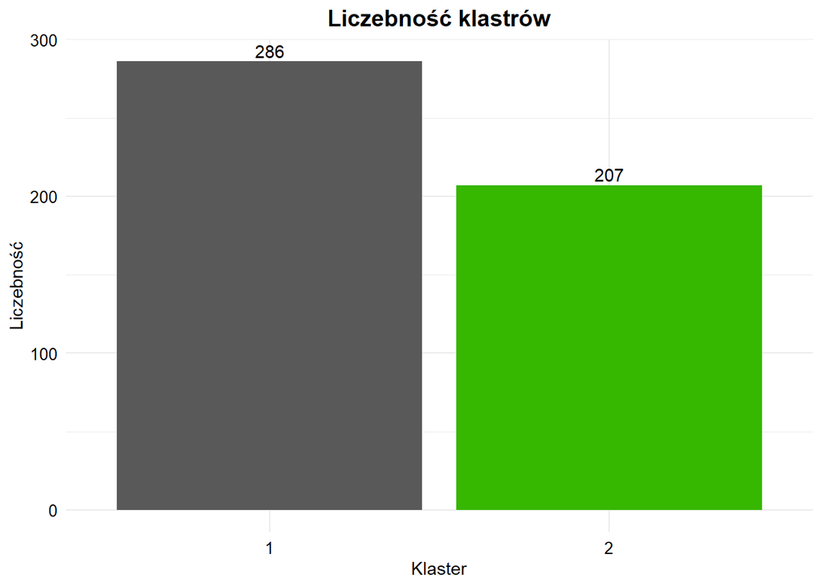

```r
Clusters_n <- data %>%
  group_by(Cluster) %>%
  count() %>%
  as.data.frame()


 ggplot(Clusters_n, aes(x = factor(Cluster), y = n, fill = factor(Cluster))) +
  geom_bar(stat = "identity") +
  scale_fill_manual(values = c("#595959", "#36b700")) +
  labs(title = "Liczebność klastrów", x = "Klaster", y = "Liczebność") +
   theme_minimal()+
  theme(plot.title = element_text(hjust = 0.5, face = "bold", size = 14),
        axis.text = element_text(size = 10, color = "black"),
        legend.position = "none") +
  geom_text(aes(label = n), vjust = -0.3) +
  scale_x_discrete(breaks = c(1, 2))
```

Skorzystano z modelu kprototypes, gdyż umożliwia on wykorzystanie zarówno zmiennych kategorycznych jak i numerycznych. Wyniki podziału przedstawione zostały na wykresach. Klastry są względnie podobnego rozmiaru - 286 oraz 207 obserwacji.

# Analiza otrzymanych klastrów

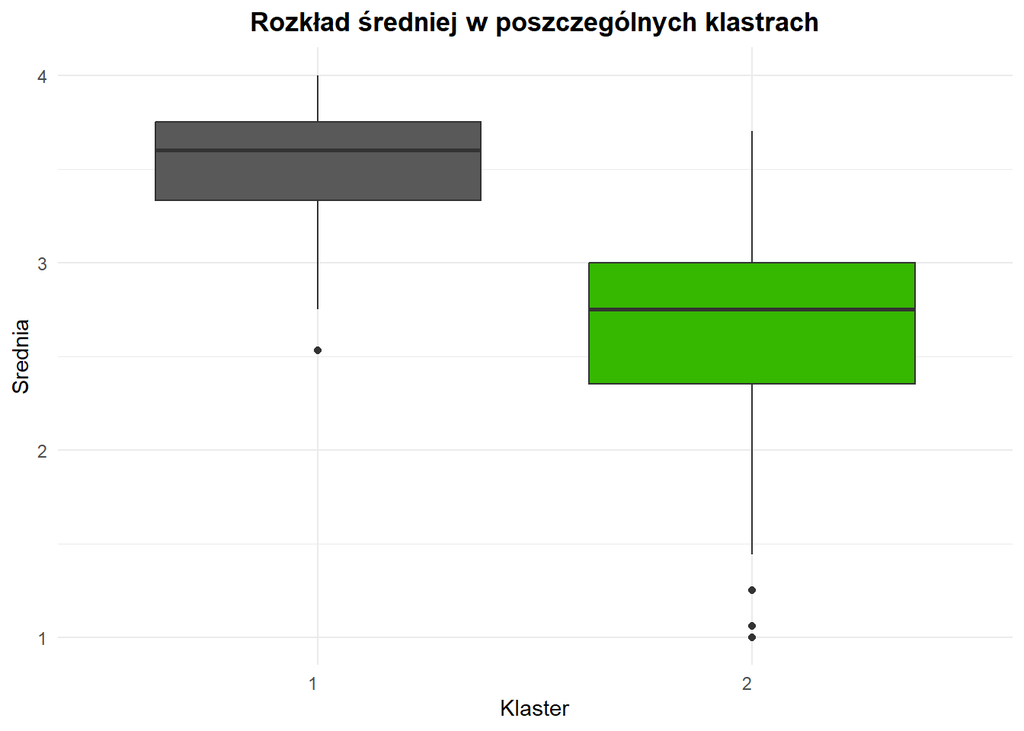

```r
ggplot(data, aes(x = Cluster , y = Overall, fill = Cluster))+
  geom_boxplot() +
  scale_fill_manual(values = c("#595959", "#36b700")) +
  theme_minimal()+
  labs(title = "Rozkład średniej w poszczególnych klastrach",
       x="Klaster",
       y="Srednia")+
  theme(plot.title = element_text(hjust = 0.5, face="bold"),
        legend.position = "none")+
   theme(axis.text.x = element_text(hjust = 1))
```

Zauważamy zdecydowaną przewagę **klastra 1** w kontekście średniej ocen.

```r
group1 <- data %>%
  filter(Cluster == 1)

group2 <- data %>%
  filter(Cluster == 2)

summary(group1)
```

```
##                                        Department     Gender         HSC
##  Computer Science and Engineering           :244   Female:108   Min.   :2.190
##  English                                    : 12   Male  :178   1st Qu.:3.947
##  Journalism, Communication and Media Studies: 10                Median :4.250
##  Business Administration                    :  5                Mean   :4.289
##  Political Science                          :  5                3rd Qu.:4.580
##  Economics                                  :  4                Max.   :5.000
##  (Other)                                    :  6
##       SSC                                Income       Hometown   Computer
##  Min.   :3.00   Low (Below 15,000)          : 48   City   :124   1: 29
##  1st Qu.:4.75   Lower middle (15,000-30,000):102   Village:162   2: 18
##  Median :5.00   Upper middle (30,000-50,000): 63                 3:105
##  Mean   :4.81   High (Above 50,000)         : 73                 4: 51
##  3rd Qu.:5.00                                                    5: 83
##  Max.   :5.00
##
##             Preparation                Gaming        Attendance   Job
##  0-1 Hour         : 68   0-1 Hour         : 45   Below 40%:  1   No :268
##  2-3 Hours        :180   2-3 Hours        :111   40%-59%  : 10   Yes: 18
##  More than 3 Hours: 38   More than 3 Hours:130   60%-79%  : 91
##                                                  80%-100% :184
##
##
##
##  English Extra        Semester        Last          Overall      Cluster
##  1:  5   No :114   2nd    :112   Min.   :1.820   Min.   :2.530   1:286
##  2: 18   Yes:172   10th   : 40   1st Qu.:3.320   1st Qu.:3.330   2:  0
##  3:155             8th    : 24   Median :3.605   Median :3.600
##  4: 48             4th    : 21   Mean   :3.559   Mean   :3.563
##  5: 60             3rd    : 16   3rd Qu.:3.837   3rd Qu.:3.750
##                    5th    : 15   Max.   :4.000   Max.   :4.000
##                    (Other): 58
```

```r
summary(group2)
```

```
##                                        Department     Gender         HSC
##  Computer Science and Engineering           :199   Female: 57   Min.   :2.170
##  Journalism, Communication and Media Studies:  3   Male  :150   1st Qu.:3.580
##  English                                    :  2                Median :4.000
##  Political Science                          :  1                Mean   :3.973
##  Public Health                              :  1                3rd Qu.:4.440
##  Sociology                                  :  1                Max.   :5.000
##  (Other)                                    :  0
##       SSC                                 Income      Hometown   Computer
##  Min.   :3.060   Low (Below 15,000)          :26   City   : 89   1:29
##  1st Qu.:4.610   Lower middle (15,000-30,000):78   Village:118   2:24
##  Median :4.820   Upper middle (30,000-50,000):47                 3:78
##  Mean   :4.709   High (Above 50,000)         :56                 4:44
##  3rd Qu.:5.000                                                   5:32
##  Max.   :5.000
##
##             Preparation                Gaming        Attendance   Job
##  0-1 Hour         :150   0-1 Hour         :  5   Below 40%: 10   No :191
##  2-3 Hours        : 48   2-3 Hours        : 30   40%-59%  : 58   Yes: 16
##  More than 3 Hours:  9   More than 3 Hours:172   60%-79%  :126
##                                                  80%-100% : 13
##
##
##
##  English Extra        Semester       Last          Overall      Cluster
##  1:  3   No :174   2nd    :71   Min.   :1.000   Min.   :1.000   1:  0
##  2: 20   Yes: 33   8th    :30   1st Qu.:2.330   1st Qu.:2.350   2:207
##  3: 21             3rd    :19   Median :2.750   Median :2.750
##  4:159             5th    :18   Mean   :2.618   Mean   :2.671
##  5:  4             10th   :17   3rd Qu.:2.995   3rd Qu.:3.000
##                    6th    :16   Max.   :3.560   Max.   :3.700
##                    (Other):36
```

```r
mean(group1$Overall)
```

```
## [1] 3.562752
```

Powyższe podsumowania pozwoliły na zauważenie ogólnych różnic i tendencji dla poszczególnych klastrów. Dodatkowo zauważamy, że średnia ocen dla klastra 1 jest bardzo wysoka i wynosi **3,56**.

## Sylwetka kandydata idealnego 2

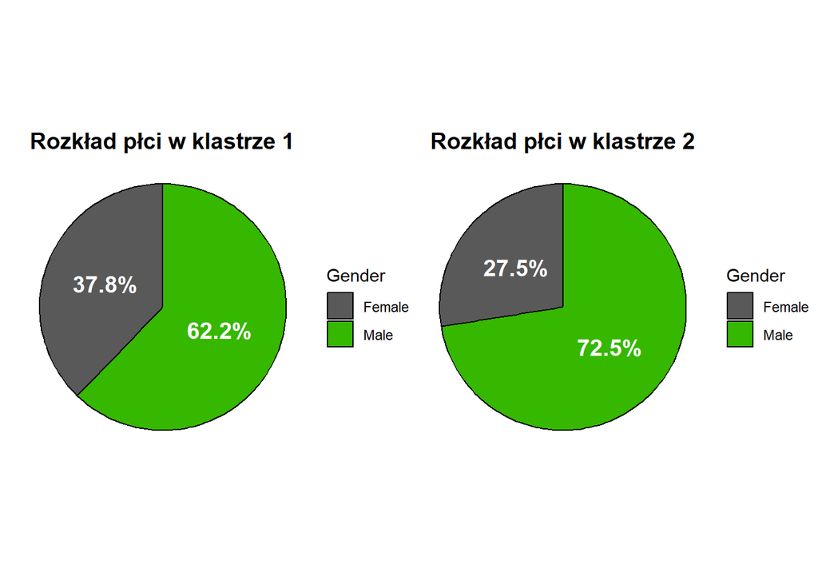

```r
group1gen <- group1 %>%
  group_by(Gender) %>%
  count() %>%
  as.data.frame()

clustgen1 <- ggplot(group1gen, aes(x = "", y = n, fill = Gender)) +
  geom_col(color = "black") +
  geom_text(aes(label = paste0(round(n/sum(n)*100, 1), '%')),
            position = position_stack(vjust = 0.5),
            size = 5,
            fontface = "bold",
            color = "white")+
  coord_polar(theta = "y") +
  scale_fill_manual(values = c("#595959", "#36b700"))+
  labs(title = "Rozkład płci w klastrze 1")+
  theme_void()+
  theme(plot.title = element_text(hjust = 0.5, face = "bold", size = 14))


group2gen <- group2 %>%
  group_by(Gender) %>%
  count() %>%
  as.data.frame()

clustgen2 <- ggplot(group2gen, aes(x = "", y = n, fill = Gender)) +
  geom_col(color = "black") +
  geom_text(aes(label = paste0(round(n/sum(n)*100, 1), '%')),
            position = position_stack(vjust = 0.5),
            size = 5,
            fontface = "bold",
            color = "white")+
  coord_polar(theta = "y") +
  scale_fill_manual(values = c("#595959", "#36b700"))+
  labs(title = "Rozkład płci w klastrze 2")+
  theme_void()+
  theme(plot.title = element_text(hjust = 0.5, face = "bold", size = 14))


(clustgen1 | clustgen2)
```

Zauważamy, iż w klastrze **1** stosunek liczby kobiet do mężczyzn jest znacznie bardziej wyrównany niż w przypadku klastra 2. Oznacza to, że kobiety mogą osiągać lepsze wyniki w nauce.

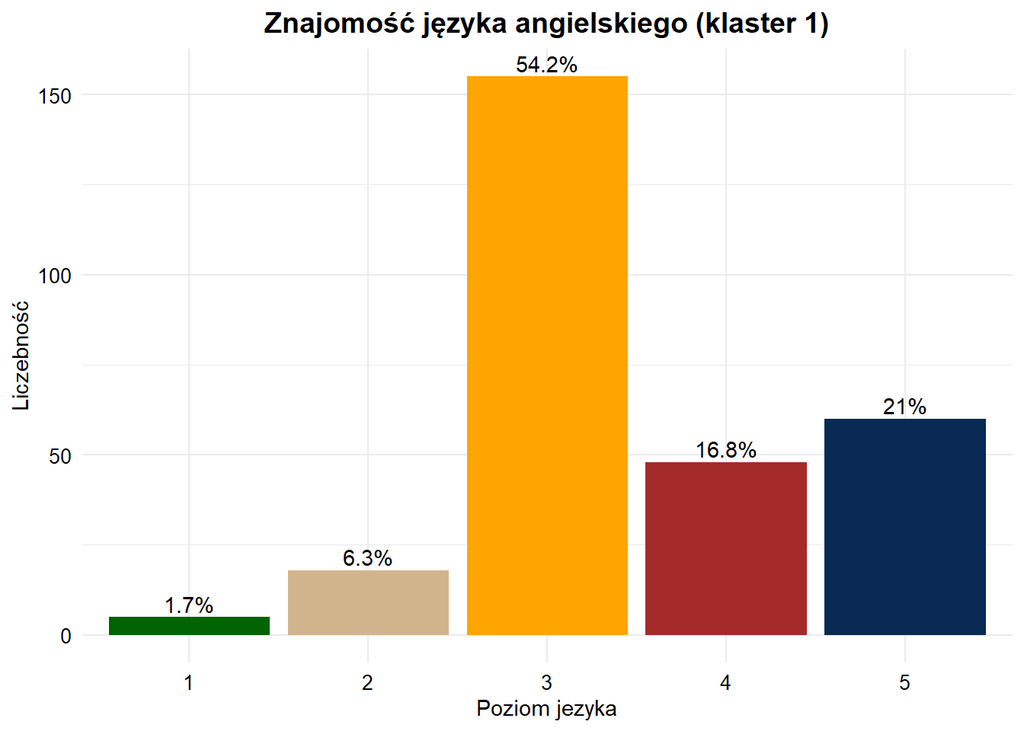

```r
group1eng <- group1 %>%
  group_by(English) %>%
  count() %>%
  as.data.frame()


ggplot(group1eng, aes(x = English, y = n, fill = English))+
  geom_bar(stat = "identity")+
  scale_fill_manual(values = c("darkgreen","tan","orange","brown","#082a54"))+
  labs(title = "Znajomość języka angielskiego (klaster 1)", x = "Poziom jezyka", y = "Liczebność")+
  theme_minimal() +
  theme(plot.title = element_text(hjust = 0.5, face = "bold", size = 14),
         axis.text = element_text(size = 10, color = "black"),
        legend.position = "none")+
  geom_text(aes(label = paste0(round(n/sum(n)*100, 1), '%'), vjust = -0.3))
```

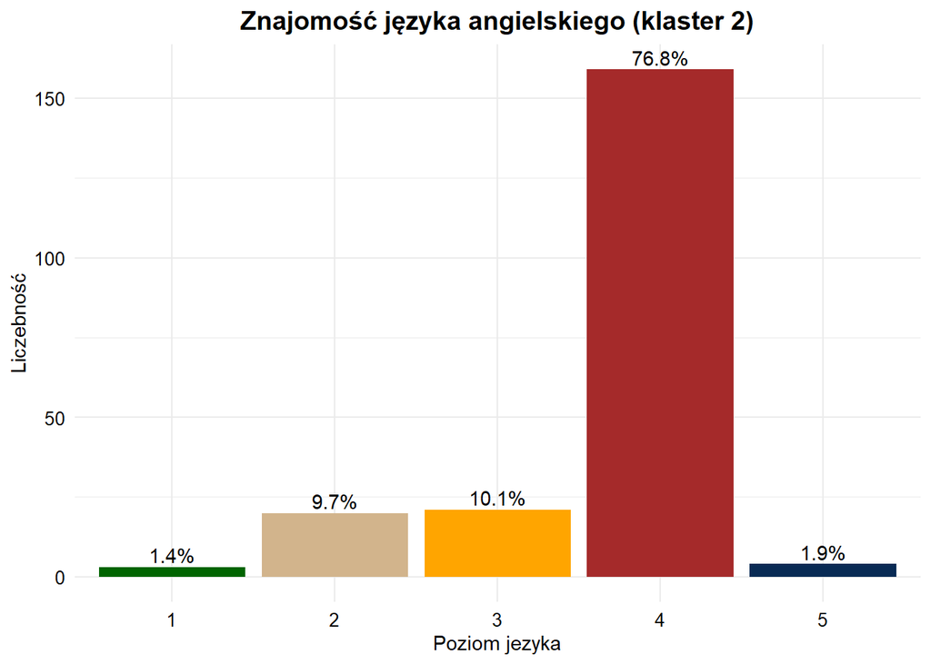

```r
group2eng <- group2 %>%
  group_by(English) %>%
  count() %>%
  as.data.frame()


ggplot(group2eng, aes(x = English, y = n, fill = English))+
  geom_bar(stat = "identity")+
  scale_fill_manual(values = c("darkgreen","tan","orange","brown","#082a54"))+
  labs(title = "Znajomość języka angielskiego (klaster 2)", x = "Poziom jezyka", y = "Liczebność")+
  theme_minimal() +
  theme(plot.title = element_text(hjust = 0.5, face = "bold", size = 14),
         axis.text = element_text(size = 10, color = "black"),
        legend.position = "none")+
  geom_text(aes(label = paste0(round(n/sum(n)*100, 1), '%'), vjust = -0.3))
```

Niesamowicie ciekawą zależność ujawniają powyższe wizualizacje. Okazuje się, że w grupie *“lepszych”* studentów poziom języka angielskiego jest raczej niższy niż w przypadku studentów *“słabszych”*. Stąd możemy wysnuć refleksję, iż znajomość języka obcego wcale nie ma tak dużego wpływu na wyniki akademickie jak mogłoby się to wydawać.

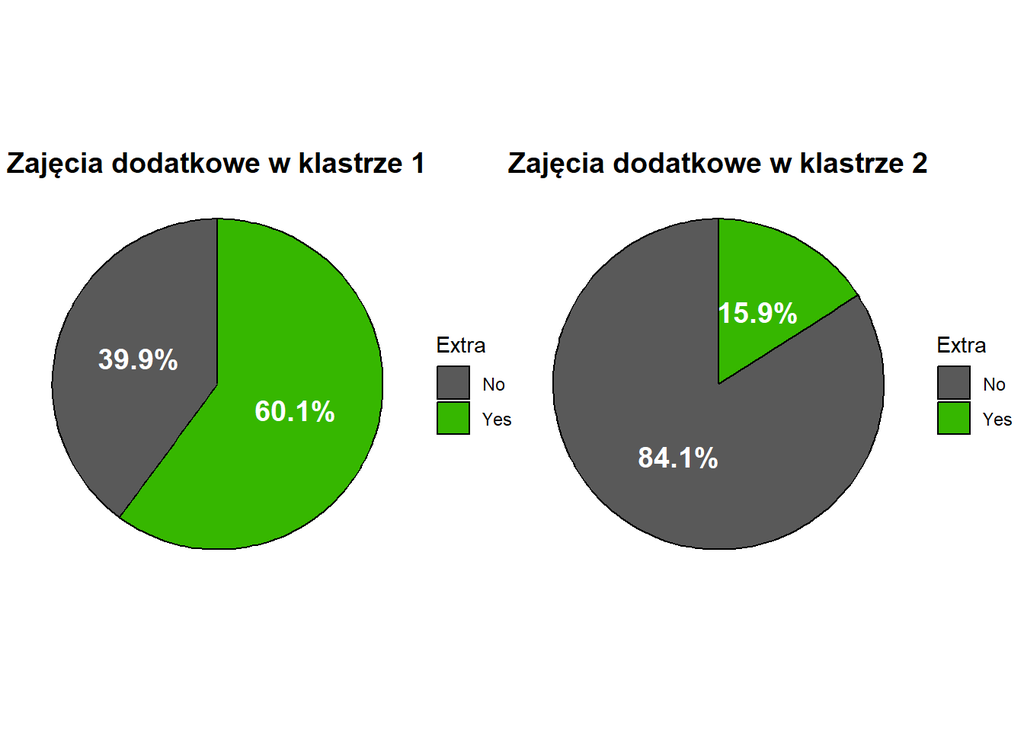

```r
group1extra <- group1 %>%
  group_by(Extra) %>%
  count() %>%
  as.data.frame()

clustextra1 <- ggplot(group1extra, aes(x = "", y = n, fill = Extra)) +
  geom_col(color = "black") +
  geom_text(aes(label = paste0(round(n/sum(n)*100, 1), '%')),
            position = position_stack(vjust = 0.5),
            size = 5,
            fontface = "bold",
            color = "white")+
  coord_polar(theta = "y") +
  scale_fill_manual(values = c("#595959", "#36b700"))+
  labs(title = "Zajęcia dodatkowe w klastrze 1")+
  theme_void()+
  theme(plot.title = element_text(hjust = 0.5, face = "bold", size = 14))


group2extra <- group2 %>%
  group_by(Extra) %>%
  count() %>%
  as.data.frame()

clustextra2 <- ggplot(group2extra, aes(x = "", y = n, fill = Extra)) +
  geom_col(color = "black") +
  geom_text(aes(label = paste0(round(n/sum(n)*100, 1), '%')),
            position = position_stack(vjust = 0.5),
            size = 5,
            fontface = "bold",
            color = "white")+
  coord_polar(theta = "y") +
  scale_fill_manual(values = c("#595959", "#36b700"))+
  labs(title = "Zajęcia dodatkowe w klastrze 2")+
  theme_void()+
  theme(plot.title = element_text(hjust = 0.5, face = "bold", size = 14))

(clustextra1 | clustextra2)
```

Powyższe wykresy pozwalają ponownie stwierdzić, iż osoby uczestniczące w zajęciach dodatkowych osiągają lepsze wyniki w nauce.

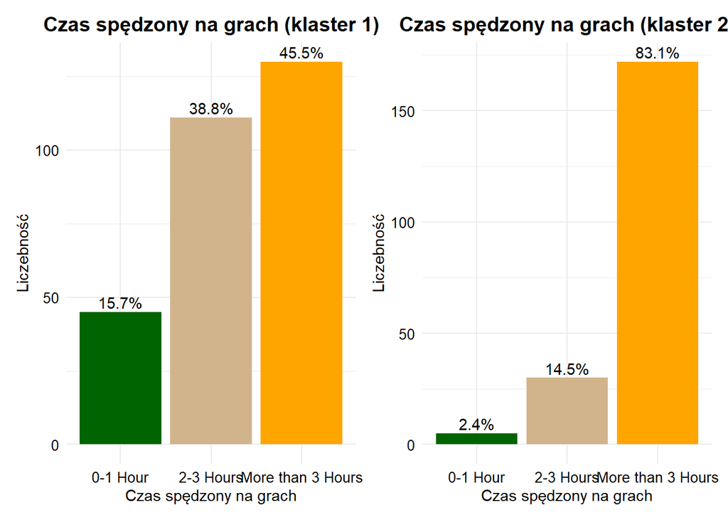

```r
group1gaming <- group1 %>%
  group_by(Gaming) %>%
  count() %>%
  as.data.frame()

clustgaming1 <- ggplot(group1gaming, aes(x = Gaming, y = n, fill = Gaming))+
  geom_bar(stat = "identity")+
  scale_fill_manual(values = c("darkgreen","tan","orange"))+
  labs(title = "Czas spędzony na grach (klaster 1)", x = "Czas spędzony na grach", y = "Liczebność")+
  theme_minimal() +
  theme(plot.title = element_text(hjust = 0.5, face = "bold", size = 14),
         axis.text = element_text(size = 10, color = "black"),
        legend.position = "none")+
  geom_text(aes(label = paste0(round(n/sum(n)*100, 1), '%'), vjust = -0.3))



group2gaming <- group2 %>%
  group_by(Gaming) %>%
  count() %>%
  as.data.frame()

clustgaming2 <- ggplot(group2gaming, aes(x = Gaming, y = n, fill = Gaming))+
  geom_bar(stat = "identity")+
  scale_fill_manual(values = c("darkgreen","tan","orange"))+
  labs(title = "Czas spędzony na grach (klaster 2)", x = "Czas spędzony na grach", y = "Liczebność")+
  theme_minimal() +
  theme(plot.title = element_text(hjust = 0.5, face = "bold", size = 14),
         axis.text = element_text(size = 10, color = "black"),
        legend.position = "none")+
  geom_text(aes(label = paste0(round(n/sum(n)*100, 1), '%'), vjust = -0.3))

(clustgaming1 | clustgaming2)
```

Interpretacja czasu spędzonego na grach daje całkiem intuicyjne wnioski tzn. osoby z wyższą średnią poświęcają mniej czasu na tego typu rozrywkę niż w przypadku osób o niższej średniej ocen.

Na podstawie powyższej analizy, możemy znów wyznaczyć sylwetkę idealnego kandydata, tym razem na znacznie bardziej reprezentatywnej próbce oraz stosunkowo niewielką utratą na średniej z ocen *(spadek o około 0,19). Wciąż świadczy to jednak o wysokich wynikach w nauce.  
Płeć: kobieta(niewielki wpływ)  
Miejsce zamieszkania: brak istotnego wpływu  
Praca: Brak  
Zajęcia dodatkowe: tak  
Gaming: <3godziny  
Angielski: Wyoski poziom nie jest wymagany

## Analiza czynników dotyczących bycia studentem

```r
data$Overallcat <- cut(
  data$Overall,
  breaks = c(1,2.5, 3.5, 4),  # Definiowanie granic przedziałów
  labels = c("Low", "Medium", "High"),  # Nazwy kategorii
  include.lowest = TRUE  # Uwzględnienie dolnej granicy
)


links_left <- data %>%
  count(source = paste("Left:", data[[8]]), target = paste("Center:", data[[17]])) %>%
  rename(value = n)

links_right <- data %>%
  count(source = paste("Center:", data[[17]]), target = paste("Right:", data[[10]])) %>%
  rename(value = n)

# Links
links <- bind_rows(links_left, links_right)


nodes <- data.frame(name = unique(c(links$source, links$target)), stringsAsFactors = FALSE)
nodes$label <- gsub("Left: |Center: |Right: ", "", nodes$name)

links$source <- match(links$source, nodes$name) - 1
links$target <- match(links$target, nodes$name) - 1

sankey <- sankeyNetwork(Links = links, Nodes = nodes,
                        Source = "source", Target = "target", Value = "value",
                        NodeID = "label", units = "Liczność", fontSize = 12,
                        nodeWidth = 30, nodePadding = 15, iterations = 0,
                        width = 700, height = 500)

title <- tags$div(
  style = "font-size: 24px; font-weight: bold; text-align: center; margin-bottom: 10px; color=black;",
  "Przygotowanie - Klaster - Obecność"
)
output <- tagList(title, sankey)

output
```

Przygotowanie - Klaster - Obecność

[interactive chart not shown]

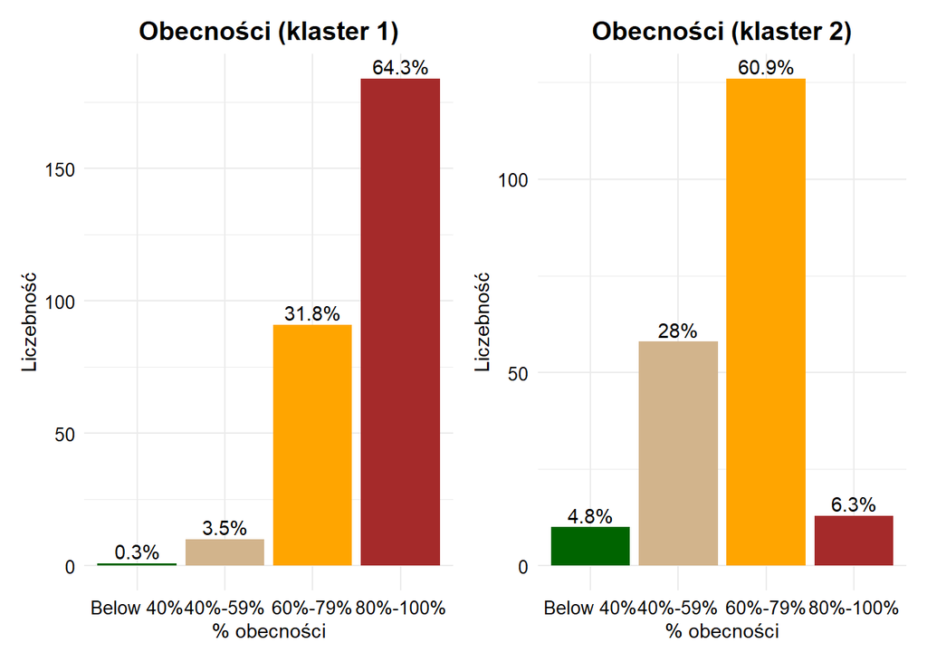

```r
group1att <- group1 %>%
  group_by(Attendance) %>%
  count() %>%
  as.data.frame()

clustatt1 <- ggplot(group1att, aes(x = Attendance, y = n, fill = Attendance))+
  geom_bar(stat = "identity")+
  scale_fill_manual(values = c("darkgreen","tan","orange","brown"))+
  labs(title = "Obecności (klaster 1)", x = "% obecności", y = "Liczebność")+
  theme_minimal() +
  theme(plot.title = element_text(hjust = 0.5, face = "bold", size = 14),
         axis.text = element_text(size = 10, color = "black"),
        legend.position = "none")+
  geom_text(aes(label = paste0(round(n/sum(n)*100, 1), '%'), vjust = -0.3))


group2att <- group2 %>%
  group_by(Attendance) %>%
  count() %>%
  as.data.frame()

clustatt2 <- ggplot(group2att, aes(x = Attendance, y = n, fill = Attendance))+
  geom_bar(stat = "identity")+
  scale_fill_manual(values = c("darkgreen","tan","orange","brown"))+
  labs(title = "Obecności (klaster 2)", x = "% obecności", y = "Liczebność")+
  theme_minimal() +
  theme(plot.title = element_text(hjust = 0.5, face = "bold", size = 14),
         axis.text = element_text(size = 10, color = "black"),
        legend.position = "none")+
  geom_text(aes(label = paste0(round(n/sum(n)*100, 1), '%'), vjust = -0.3))


(clustatt1 | clustatt2)
```

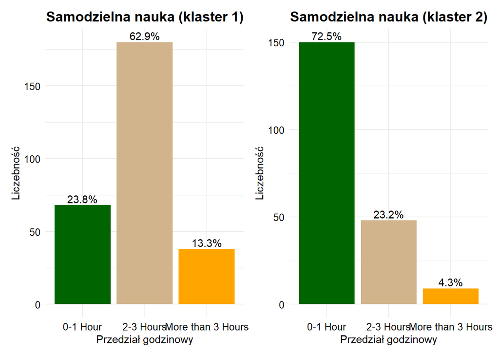

```r
group1prep <- group1 %>%
  group_by(Preparation) %>%
  count() %>%
  as.data.frame()

clustprep1 <- ggplot(group1prep, aes(x = Preparation, y = n, fill = Preparation))+
  geom_bar(stat = "identity")+
  scale_fill_manual(values = c("darkgreen","tan","orange"))+
  labs(title = "Samodzielna nauka (klaster 1)", x = "Przedział godzinowy", y = "Liczebność")+
  theme_minimal() +
  theme(plot.title = element_text(hjust = 0.5, face = "bold", size = 14),
         axis.text = element_text(size = 10, color = "black"),
        legend.position = "none")+
  geom_text(aes(label = paste0(round(n/sum(n)*100, 1), '%'), vjust = -0.3))



group2prep <- group2 %>%
  group_by(Preparation) %>%
  count() %>%
  as.data.frame()

clustprep2 <- ggplot(group2prep, aes(x = Preparation, y = n, fill = Preparation))+
  geom_bar(stat = "identity")+
  scale_fill_manual(values = c("darkgreen","tan","orange"))+
  labs(title = "Samodzielna nauka (klaster 2)", x = "Przedział godzinowy", y = "Liczebność")+
  theme_minimal() +
  theme(plot.title = element_text(hjust = 0.5, face = "bold", size = 14),
         axis.text = element_text(size = 10, color = "black"),
        legend.position = "none")+
  geom_text(aes(label = paste0(round(n/sum(n)*100, 1), '%'), vjust = -0.3))

(clustprep1 | clustprep2)
```

Powyższe wykresy przedstawiają rozkład pewnych cech dotyczących nie kandydatów, a osób już studiujących i potwierdzają wnioski wysnute dla ogółu ankietowanych. Ponownie widzimy, że wraz ze osoby z lepszą frekwencją i większą liczbą godzin poświęconych na dodatkową naukę osiągją lepsze wyniki.

# Analiza regresji, SLR Model

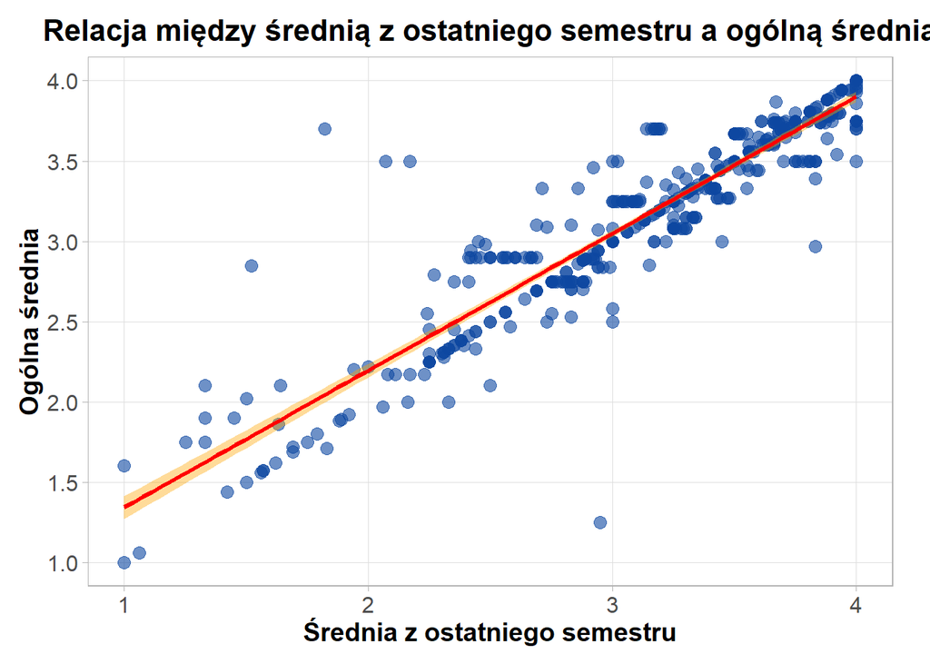

```r
ggplot(data, aes(x = Last, y = Overall)) +
  # Punkty
  geom_point(alpha = 0.6, color = "#0D47A1", size = 3) +
  # Linia regresji z cieniem
  geom_smooth(method = "lm", color = "red", se = TRUE, fill = "orange", linewidth = 1.2) +
  # Tytuł i etykiety
  labs(
    title = "Relacja między średnią z ostatniego semestru a ogólną średnią",
    x = "Średnia z ostatniego semestru",
    y = "Ogólna średnia"
  ) +
  # Motyw wykresu
  theme_light() +
  theme(plot.title = element_text(hjust = 0.5, size = 16, face = "bold"),
    axis.title = element_text(size = 14, face = "bold"),
    axis.text = element_text(size = 12),
    panel.grid.minor = element_blank(),  # Brak siatki pomocniczej
    plot.margin = margin(10, 20, 10, 10)) +
  scale_x_continuous(breaks = seq(min(data$Last), max(data$Last), by = 1)) +
  scale_y_continuous(breaks = seq(min(data$Overall), max(data$Overall), by = 0.5))
```

```r
model <- lm(Overall ~ Last, data = data)
summary(model)
```

```
##
## Call:
## lm(formula = Overall ~ Last, data = data)
##
## Residuals:
##      Min       1Q   Median       3Q      Max
## -1.75584 -0.13636 -0.00446  0.08925  1.65855
##
## Coefficients:
##             Estimate Std. Error t value Pr(>|t|)
## (Intercept)  0.48819    0.05104   9.564   <2e-16 ***
## Last         0.85344    0.01581  53.974   <2e-16 ***
## ---
## Signif. codes:  0 '***' 0.001 '**' 0.01 '*' 0.05 '.' 0.1 ' ' 1
##
## Residual standard error: 0.225 on 491 degrees of freedom
## Multiple R-squared:  0.8558, Adjusted R-squared:  0.8555
## F-statistic:  2913 on 1 and 491 DF,  p-value: < 2.2e-16
```

```r
reszty <- model$residuals
```

## Założenia

### Relacja liniowa

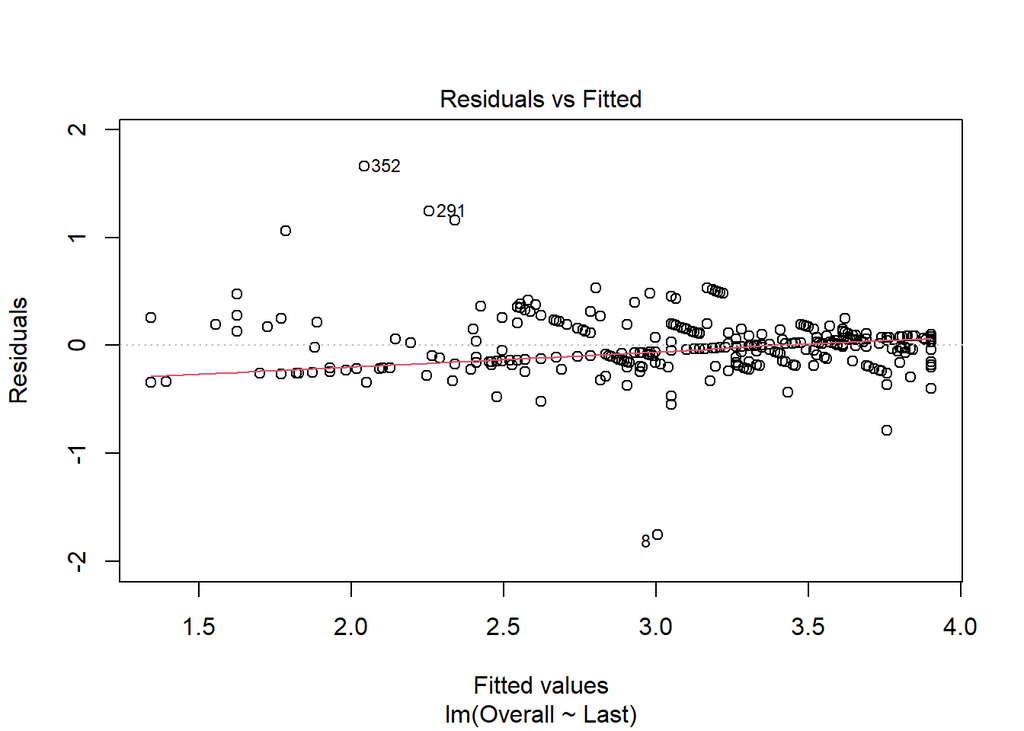

```r
plot(model,1)
```

Założenie to jest spełnione- w calym obszarze zmiennosci Y reszty rozkładają się równomiernie - linia jest względnie prosta.

### Reszty mają rozkład normalny

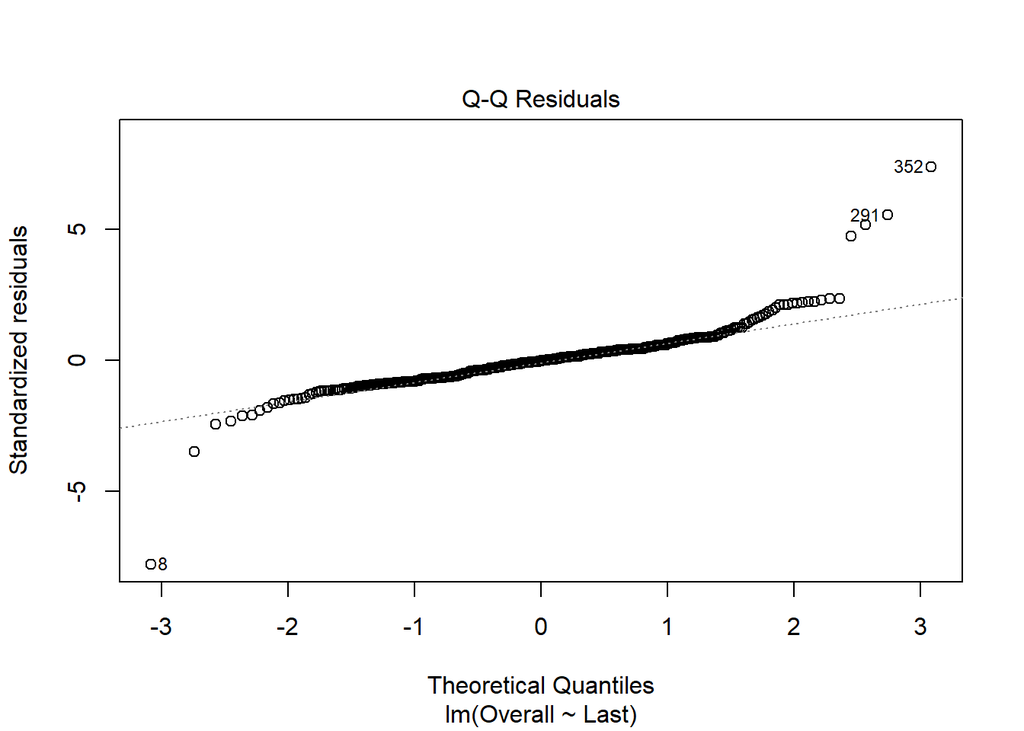

```r
plot(model,2)
```

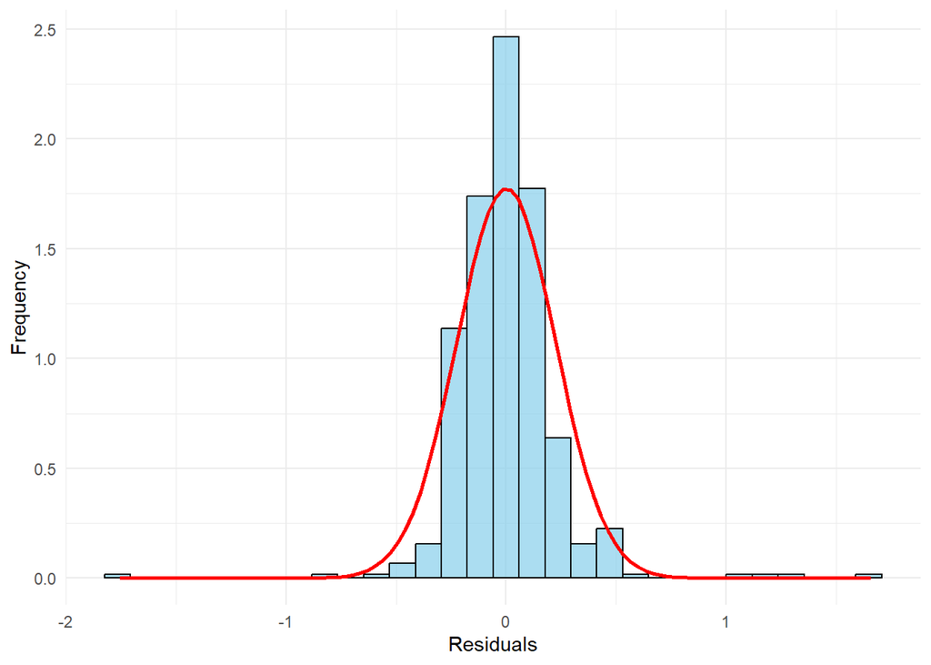

```r
ggplot(data.frame(reszty), aes(x = reszty)) +
  geom_histogram(aes(y = ..density..), bins = 30, fill = "skyblue", color = "black", alpha = 0.7) +
  stat_function(fun = dnorm, args = list(mean = mean(reszty), sd = sd(reszty)), color = "red", size = 1) +
  theme_minimal() +
  labs(x = "Residuals",
       y = "Frequency")
```

### Homoscedastyczność

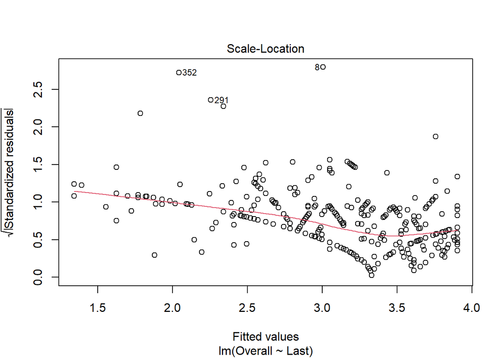

```r
plot(model,3)
```

### Znaczenie wartosci ekstremalnych

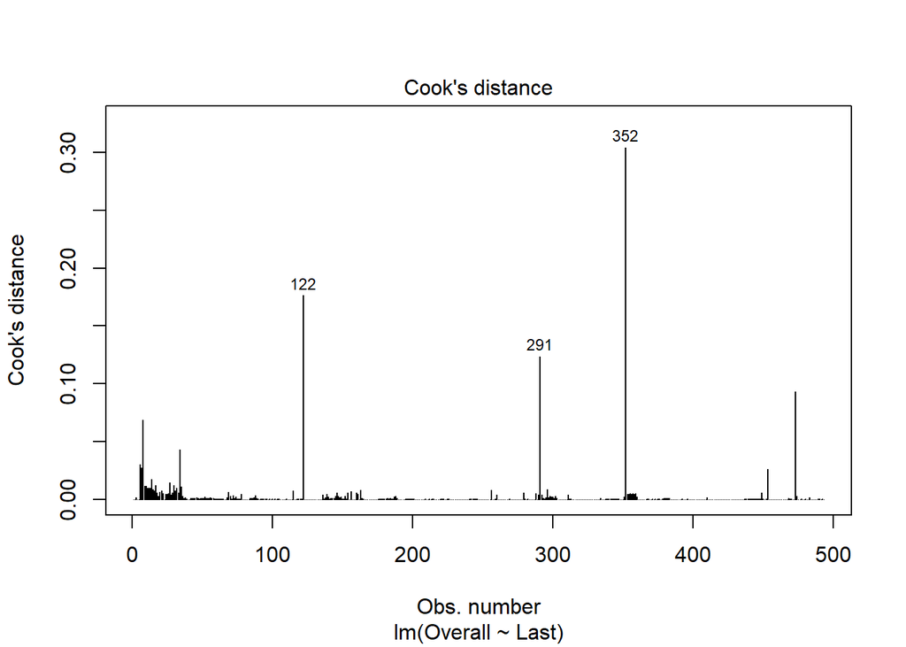

```r
plot(model,4)
```

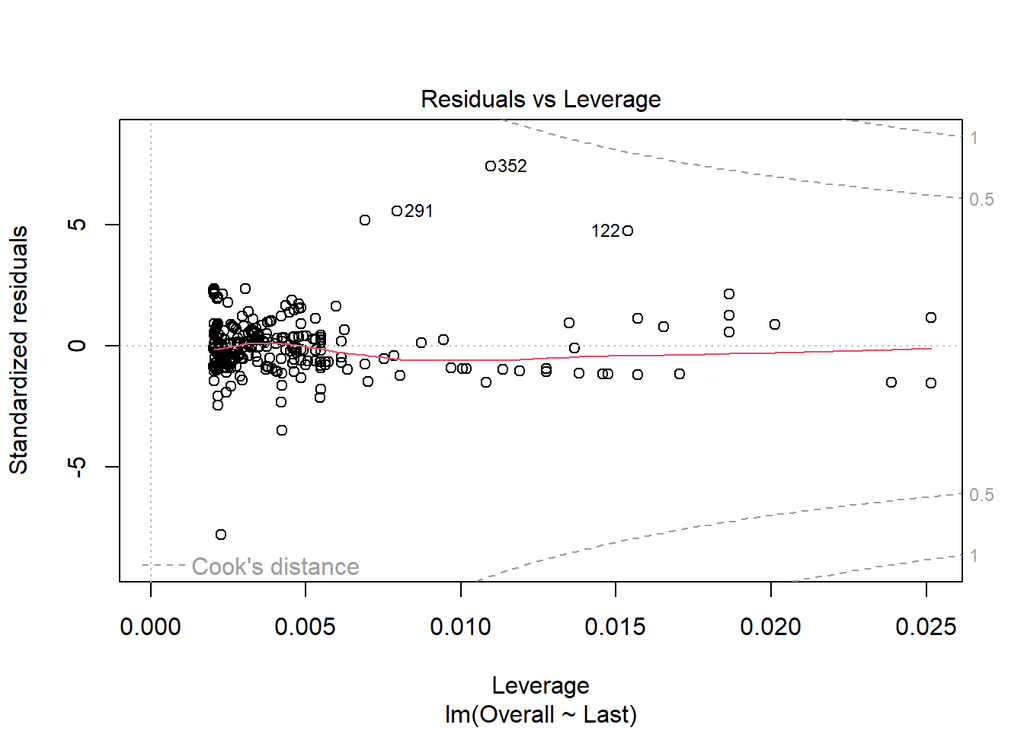

```r
plot(model,5) # wartosci wyraznie odbierajace od lini wzgleden osi y - outlier
```

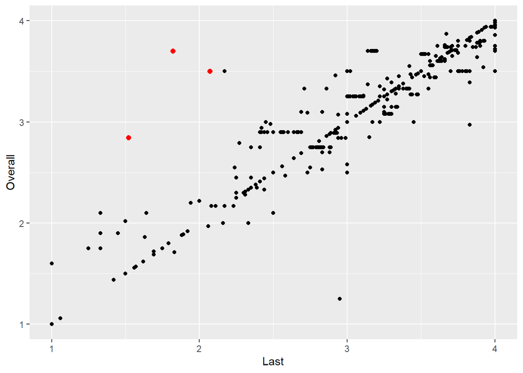

```r
              # wartosci odbiegajace znacznie od innych na osi x - High-leverage point
data3 <- data[c(122,291,352),]
ggplot()+
  geom_point(data = data, aes(x = Last, y = Overall))+
  geom_point(data = data3, aes(x = Last, y = Overall), color = "red", size = 2)
```

Warunek spełniony- żadne obserwacje nie zmieniają znacząco modelu

# Link do Github

https://github.com/Dawid-Palka/MPiWD-Projekt